# 收集

```python
import pandas as pd
import numpy as np
import requests
from bs4 import BeautifulSoup
import json
import re
import matplotlib.pyplot as plt
% matplotlib inline
```

```python
# twitter_archive_enhanced.csv是给定的文件
df1=pd.read_csv('twitter_archive_enhanced.csv')
```

```python
# 用requests.get(url)下载给出url的文件
url='https://raw.githubusercontent.com/udacity/new-dand-advanced-china/master/%E6%95%B0%E6%8D%AE%E6%B8%85%E6%B4%97/WeRateDogs%E9%A1%B9%E7%9B%AE/image-predictions.tsv'
response=requests.get(url)

# 如果直接打开文件，文件名用引号，如with open ('image-predictions.tsv','w')as file:
with open (url.split('/')[-1],'w')as file:
    file.write(response.text)

# tsv 是平面文件,所以可以把text(文本文件)，打开为tsv格式
# image_predictions.tsv是以编程方式下载的文件
df2=pd.read_table('image_predictions.tsv',"\t")
```

```python
#
# 通过tweepy API，直接读取到数据框df3。是最快的方式。
# 不要在提交时包含 API 密钥和访问令牌。这是 API 和公共代码的标准惯例。
import tweepy
consumer_key = ''
consumer_secret = ''
access_token = ''
access_secret = ''
auth = tweepy.OAuthHandler(consumer_key, consumer_secret)
auth.set_access_token(access_token, access_secret)
api = tweepy.API(auth,wait_on_rate_limit = True ,wait_on_rate_limit_notify = True )


df3=pd.DataFrame(columns=['tweet_id','retweet_count','favorite_count'])

with open('tweet_temp_json.txt','w') as file:    # 放在for loop中的话，会导致每一次循环都打开关闭一次文件，浪费时间
    for tweet_id in df1.tweet_id:
        try:
            data = api.get_status(tweet_id,tweet_mode='extended')._json   # 提取成json格式
            api.statuses_lookup(tweet_id,tweet_mode='extended')
            file.write(data)  # 写入文件
            df3=df3.append([{'tweet_id':data['id'],'retweet_count':data['retweet_count'],
                        'favorite_count':data['favorite_count']}],ignore_index=True) # 同时提取需要的数据
            print(tweet_id,'success')
        except:
            print(tweet_id,':','ID is not exist')
```

```python
#
# 从tweepy API下载文件tweet_json.txt
# 不要在提交时包含 API 密钥和访问令牌。这是 API 和公共代码的标准惯例。
import tweepy
consumer_key = ''
consumer_secret = ''
access_token = ''
access_secret = ''
auth = tweepy.OAuthHandler(consumer_key, consumer_secret)
auth.set_access_token(access_token, access_secret)
api = tweepy.API(auth,wait_on_rate_limit = True ,wait_on_rate_limit_notify = True )

# 方法一：for在with外，使用‘a’
# 获取数字id：读df1的tweet_id列，写一个列表
tweet_id_list = list(df1.tweet_id)
for tweet_id in tweet_id_list:

    try:
        tweet = api.get_status(tweet_id, tweet_mode='extended')

        with open('tweet_json.txt', 'a') as outfile:    # 'a'以附加写的方式打开，没有的会创建
            json.dumps(tweet.text, outfile)     # json.dumps转换为的是str字符串的形式，json.dump转换为的是data。（json.loads和json.load同）
    except:
        print(tweet_id,':','ID is not exist')

# 方法二：with在for外，使用‘w’
with open('tweet_json.txt', 'w') as outfile:
    for tweet_id in df1.tweet_id:
        try:
            tweet = api.get_status(tweet_id, tweet_mode='extended')
            json.dumps(tweet.text, outfile)
        except:
            print(tweet_id,':','ID is not exist')
```

```python
# tweet_json.txt应该是通过API构建的文件。此处直接读取，与ipynb文件同一文件夹的tweet_json.txt
# 方法一：
df_list = []

with open('tweet_json.txt')as file:
    while True:
        lines = file.readline() # 每行是一个tweet,逐行读取数据，每行中获取需要内容
        if not lines:
            break
        parsed_json=json.loads(lines)  # tweet_json.txt是json文件，用json.loads(lines)转换为普通可读取的字典
        tweet_id=parsed_json['id']
        retweet_count=parsed_json['retweet_count']
        favorite_count=parsed_json['favorite_count']
        full_text=parsed_json['full_text']
        df_list.append({'tweet_id':tweet_id,'retweet_count':retweet_count,
                        'favorite_count':favorite_count,'full_text':full_text})
df3=pd.DataFrame(df_list,columns=['tweet_id','retweet_count','favorite_count','full_text'])
```

```python
# tweet_json.txt应该是通过API构建的文件。此处直接读取，与ipynb文件同一文件夹的tweet_json.txt
# 方法二：
df_list=[]
with open('tweet_json.txt','r') as file:
    for row in file:
        json_dict= json.loads(row)
        to_append= {
            'tweet_id':json_dict['id'],
            'retweet_count':json_dict['retweet_count'],
            'favorite_count':json_dict['favorite_count']
        }
        df_list.append(to_append)
df3=pd.DataFrame(df_list, columns=['tweet_id','retweet_count','favorite_count'])
```

```python
# 保留原表，新建副本用于评估清理
df_twi=df1.copy()
df_imgpre=df2.copy()
df_count=df3.copy()
```

# 评估

```python
df_twi
```

|  | tweet_id | in_reply_to_status_id | in_reply_to_user_id | timestamp | source | text | retweeted_status_id | retweeted_status_user_id | retweeted_status_timestamp | expanded_urls | rating_numerator | rating_denominator | name | doggo | floofer | pupper | puppo |
| --- | --- | --- | --- | --- | --- | --- | --- | --- | --- | --- | --- | --- | --- | --- | --- | --- | --- |
| 0 | 892420643555336193 | NaN | NaN | 2017-08-01 16:23:56 +0000 | <a href="http://twitter.com/download/iphone" r... | This is Phineas. He's a mystical boy. Only eve... | NaN | NaN | NaN | https://twitter.com/dog_rates/status/892420643... | 13 | 10 | Phineas | None | None | None | None |
| 1 | 892177421306343426 | NaN | NaN | 2017-08-01 00:17:27 +0000 | <a href="http://twitter.com/download/iphone" r... | This is Tilly. She's just checking pup on you.... | NaN | NaN | NaN | https://twitter.com/dog_rates/status/892177421... | 13 | 10 | Tilly | None | None | None | None |
| 2 | 891815181378084864 | NaN | NaN | 2017-07-31 00:18:03 +0000 | <a href="http://twitter.com/download/iphone" r... | This is Archie. He is a rare Norwegian Pouncin... | NaN | NaN | NaN | https://twitter.com/dog_rates/status/891815181... | 12 | 10 | Archie | None | None | None | None |
| 3 | 891689557279858688 | NaN | NaN | 2017-07-30 15:58:51 +0000 | <a href="http://twitter.com/download/iphone" r... | This is Darla. She commenced a snooze mid meal... | NaN | NaN | NaN | https://twitter.com/dog_rates/status/891689557... | 13 | 10 | Darla | None | None | None | None |
| 4 | 891327558926688256 | NaN | NaN | 2017-07-29 16:00:24 +0000 | <a href="http://twitter.com/download/iphone" r... | This is Franklin. He would like you to stop ca... | NaN | NaN | NaN | https://twitter.com/dog_rates/status/891327558... | 12 | 10 | Franklin | None | None | None | None |
| 5 | 891087950875897856 | NaN | NaN | 2017-07-29 00:08:17 +0000 | <a href="http://twitter.com/download/iphone" r... | Here we have a majestic great white breaching ... | NaN | NaN | NaN | https://twitter.com/dog_rates/status/891087950... | 13 | 10 | None | None | None | None | None |
| 6 | 890971913173991426 | NaN | NaN | 2017-07-28 16:27:12 +0000 | <a href="http://twitter.com/download/iphone" r... | Meet Jax. He enjoys ice cream so much he gets ... | NaN | NaN | NaN | https://gofundme.com/ydvmve-surgery-for-jax,ht... | 13 | 10 | Jax | None | None | None | None |
| 7 | 890729181411237888 | NaN | NaN | 2017-07-28 00:22:40 +0000 | <a href="http://twitter.com/download/iphone" r... | When you watch your owner call another dog a g... | NaN | NaN | NaN | https://twitter.com/dog_rates/status/890729181... | 13 | 10 | None | None | None | None | None |
| 8 | 890609185150312448 | NaN | NaN | 2017-07-27 16:25:51 +0000 | <a href="http://twitter.com/download/iphone" r... | This is Zoey. She doesn't want to be one of th... | NaN | NaN | NaN | https://twitter.com/dog_rates/status/890609185... | 13 | 10 | Zoey | None | None | None | None |
| 9 | 890240255349198849 | NaN | NaN | 2017-07-26 15:59:51 +0000 | <a href="http://twitter.com/download/iphone" r... | This is Cassie. She is a college pup. Studying... | NaN | NaN | NaN | https://twitter.com/dog_rates/status/890240255... | 14 | 10 | Cassie | doggo | None | None | None |
| 10 | 890006608113172480 | NaN | NaN | 2017-07-26 00:31:25 +0000 | <a href="http://twitter.com/download/iphone" r... | This is Koda. He is a South Australian decksha... | NaN | NaN | NaN | https://twitter.com/dog_rates/status/890006608... | 13 | 10 | Koda | None | None | None | None |
| 11 | 889880896479866881 | NaN | NaN | 2017-07-25 16:11:53 +0000 | <a href="http://twitter.com/download/iphone" r... | This is Bruno. He is a service shark. Only get... | NaN | NaN | NaN | https://twitter.com/dog_rates/status/889880896... | 13 | 10 | Bruno | None | None | None | None |
| 12 | 889665388333682689 | NaN | NaN | 2017-07-25 01:55:32 +0000 | <a href="http://twitter.com/download/iphone" r... | Here's a puppo that seems to be on the fence a... | NaN | NaN | NaN | https://twitter.com/dog_rates/status/889665388... | 13 | 10 | None | None | None | None | puppo |
| 13 | 889638837579907072 | NaN | NaN | 2017-07-25 00:10:02 +0000 | <a href="http://twitter.com/download/iphone" r... | This is Ted. He does his best. Sometimes that'... | NaN | NaN | NaN | https://twitter.com/dog_rates/status/889638837... | 12 | 10 | Ted | None | None | None | None |
| 14 | 889531135344209921 | NaN | NaN | 2017-07-24 17:02:04 +0000 | <a href="http://twitter.com/download/iphone" r... | This is Stuart. He's sporting his favorite fan... | NaN | NaN | NaN | https://twitter.com/dog_rates/status/889531135... | 13 | 10 | Stuart | None | None | None | puppo |
| 15 | 889278841981685760 | NaN | NaN | 2017-07-24 00:19:32 +0000 | <a href="http://twitter.com/download/iphone" r... | This is Oliver. You're witnessing one of his m... | NaN | NaN | NaN | https://twitter.com/dog_rates/status/889278841... | 13 | 10 | Oliver | None | None | None | None |
| 16 | 888917238123831296 | NaN | NaN | 2017-07-23 00:22:39 +0000 | <a href="http://twitter.com/download/iphone" r... | This is Jim. He found a fren. Taught him how t... | NaN | NaN | NaN | https://twitter.com/dog_rates/status/888917238... | 12 | 10 | Jim | None | None | None | None |
| 17 | 888804989199671297 | NaN | NaN | 2017-07-22 16:56:37 +0000 | <a href="http://twitter.com/download/iphone" r... | This is Zeke. He has a new stick. Very proud o... | NaN | NaN | NaN | https://twitter.com/dog_rates/status/888804989... | 13 | 10 | Zeke | None | None | None | None |
| 18 | 888554962724278272 | NaN | NaN | 2017-07-22 00:23:06 +0000 | <a href="http://twitter.com/download/iphone" r... | This is Ralphus. He's powering up. Attempting ... | NaN | NaN | NaN | https://twitter.com/dog_rates/status/888554962... | 13 | 10 | Ralphus | None | None | None | None |
| 19 | 888202515573088257 | NaN | NaN | 2017-07-21 01:02:36 +0000 | <a href="http://twitter.com/download/iphone" r... | RT @dog_rates: This is Canela. She attempted s... | 8.874740e+17 | 4.196984e+09 | 2017-07-19 00:47:34 +0000 | https://twitter.com/dog_rates/status/887473957... | 13 | 10 | Canela | None | None | None | None |
| 20 | 888078434458587136 | NaN | NaN | 2017-07-20 16:49:33 +0000 | <a href="http://twitter.com/download/iphone" r... | This is Gerald. He was just told he didn't get... | NaN | NaN | NaN | https://twitter.com/dog_rates/status/888078434... | 12 | 10 | Gerald | None | None | None | None |
| 21 | 887705289381826560 | NaN | NaN | 2017-07-19 16:06:48 +0000 | <a href="http://twitter.com/download/iphone" r... | This is Jeffrey. He has a monopoly on the pool... | NaN | NaN | NaN | https://twitter.com/dog_rates/status/887705289... | 13 | 10 | Jeffrey | None | None | None | None |
| 22 | 887517139158093824 | NaN | NaN | 2017-07-19 03:39:09 +0000 | <a href="http://twitter.com/download/iphone" r... | I've yet to rate a Venezuelan Hover Wiener. Th... | NaN | NaN | NaN | https://twitter.com/dog_rates/status/887517139... | 14 | 10 | such | None | None | None | None |
| 23 | 887473957103951883 | NaN | NaN | 2017-07-19 00:47:34 +0000 | <a href="http://twitter.com/download/iphone" r... | This is Canela. She attempted some fancy porch... | NaN | NaN | NaN | https://twitter.com/dog_rates/status/887473957... | 13 | 10 | Canela | None | None | None | None |
| 24 | 887343217045368832 | NaN | NaN | 2017-07-18 16:08:03 +0000 | <a href="http://twitter.com/download/iphone" r... | You may not have known you needed to see this ... | NaN | NaN | NaN | https://twitter.com/dog_rates/status/887343217... | 13 | 10 | None | None | None | None | None |
| 25 | 887101392804085760 | NaN | NaN | 2017-07-18 00:07:08 +0000 | <a href="http://twitter.com/download/iphone" r... | This... is a Jubilant Antarctic House Bear. We... | NaN | NaN | NaN | https://twitter.com/dog_rates/status/887101392... | 12 | 10 | None | None | None | None | None |
| 26 | 886983233522544640 | NaN | NaN | 2017-07-17 16:17:36 +0000 | <a href="http://twitter.com/download/iphone" r... | This is Maya. She's very shy. Rarely leaves he... | NaN | NaN | NaN | https://twitter.com/dog_rates/status/886983233... | 13 | 10 | Maya | None | None | None | None |
| 27 | 886736880519319552 | NaN | NaN | 2017-07-16 23:58:41 +0000 | <a href="http://twitter.com/download/iphone" r... | This is Mingus. He's a wonderful father to his... | NaN | NaN | NaN | https://www.gofundme.com/mingusneedsus,https:/... | 13 | 10 | Mingus | None | None | None | None |
| 28 | 886680336477933568 | NaN | NaN | 2017-07-16 20:14:00 +0000 | <a href="http://twitter.com/download/iphone" r... | This is Derek. He's late for a dog meeting. 13... | NaN | NaN | NaN | https://twitter.com/dog_rates/status/886680336... | 13 | 10 | Derek | None | None | None | None |
| 29 | 886366144734445568 | NaN | NaN | 2017-07-15 23:25:31 +0000 | <a href="http://twitter.com/download/iphone" r... | This is Roscoe. Another pupper fallen victim t... | NaN | NaN | NaN | https://twitter.com/dog_rates/status/886366144... | 12 | 10 | Roscoe | None | None | pupper | None |
| ... | ... | ... | ... | ... | ... | ... | ... | ... | ... | ... | ... | ... | ... | ... | ... | ... | ... |
| 2326 | 666411507551481857 | NaN | NaN | 2015-11-17 00:24:19 +0000 | <a href="http://twitter.com/download/iphone" r... | This is quite the dog. Gets really excited whe... | NaN | NaN | NaN | https://twitter.com/dog_rates/status/666411507... | 2 | 10 | quite | None | None | None | None |
| 2327 | 666407126856765440 | NaN | NaN | 2015-11-17 00:06:54 +0000 | <a href="http://twitter.com/download/iphone" r... | This is a southern Vesuvius bumblegruff. Can d... | NaN | NaN | NaN | https://twitter.com/dog_rates/status/666407126... | 7 | 10 | a | None | None | None | None |
| 2328 | 666396247373291520 | NaN | NaN | 2015-11-16 23:23:41 +0000 | <a href="http://twitter.com/download/iphone" r... | Oh goodness. A super rare northeast Qdoba kang... | NaN | NaN | NaN | https://twitter.com/dog_rates/status/666396247... | 9 | 10 | None | None | None | None | None |
| 2329 | 666373753744588802 | NaN | NaN | 2015-11-16 21:54:18 +0000 | <a href="http://twitter.com/download/iphone" r... | Those are sunglasses and a jean jacket. 11/10 ... | NaN | NaN | NaN | https://twitter.com/dog_rates/status/666373753... | 11 | 10 | None | None | None | None | None |
| 2330 | 666362758909284353 | NaN | NaN | 2015-11-16 21:10:36 +0000 | <a href="http://twitter.com/download/iphone" r... | Unique dog here. Very small. Lives in containe... | NaN | NaN | NaN | https://twitter.com/dog_rates/status/666362758... | 6 | 10 | None | None | None | None | None |
| 2331 | 666353288456101888 | NaN | NaN | 2015-11-16 20:32:58 +0000 | <a href="http://twitter.com/download/iphone" r... | Here we have a mixed Asiago from the Galápagos... | NaN | NaN | NaN | https://twitter.com/dog_rates/status/666353288... | 8 | 10 | None | None | None | None | None |
| 2332 | 666345417576210432 | NaN | NaN | 2015-11-16 20:01:42 +0000 | <a href="http://twitter.com/download/iphone" r... | Look at this jokester thinking seat belt laws ... | NaN | NaN | NaN | https://twitter.com/dog_rates/status/666345417... | 10 | 10 | None | None | None | None | None |
| 2333 | 666337882303524864 | NaN | NaN | 2015-11-16 19:31:45 +0000 | <a href="http://twitter.com/download/iphone" r... | This is an extremely rare horned Parthenon. No... | NaN | NaN | NaN | https://twitter.com/dog_rates/status/666337882... | 9 | 10 | an | None | None | None | None |
| 2334 | 666293911632134144 | NaN | NaN | 2015-11-16 16:37:02 +0000 | <a href="http://twitter.com/download/iphone" r... | This is a funny dog. Weird toes. Won't come do... | NaN | NaN | NaN | https://twitter.com/dog_rates/status/666293911... | 3 | 10 | a | None | None | None | None |
| 2335 | 666287406224695296 | NaN | NaN | 2015-11-16 16:11:11 +0000 | <a href="http://twitter.com/download/iphone" r... | This is an Albanian 3 1/2 legged Episcopalian... | NaN | NaN | NaN | https://twitter.com/dog_rates/status/666287406... | 1 | 2 | an | None | None | None | None |
| 2336 | 666273097616637952 | NaN | NaN | 2015-11-16 15:14:19 +0000 | <a href="http://twitter.com/download/iphone" r... | Can take selfies 11/10 https://t.co/ws2AMaNwPW | NaN | NaN | NaN | https://twitter.com/dog_rates/status/666273097... | 11 | 10 | None | None | None | None | None |
| 2337 | 666268910803644416 | NaN | NaN | 2015-11-16 14:57:41 +0000 | <a href="http://twitter.com/download/iphone" r... | Very concerned about fellow dog trapped in com... | NaN | NaN | NaN | https://twitter.com/dog_rates/status/666268910... | 10 | 10 | None | None | None | None | None |
| 2338 | 666104133288665088 | NaN | NaN | 2015-11-16 04:02:55 +0000 | <a href="http://twitter.com/download/iphone" r... | Not familiar with this breed. No tail (weird).... | NaN | NaN | NaN | https://twitter.com/dog_rates/status/666104133... | 1 | 10 | None | None | None | None | None |
| 2339 | 666102155909144576 | NaN | NaN | 2015-11-16 03:55:04 +0000 | <a href="http://twitter.com/download/iphone" r... | Oh my. Here you are seeing an Adobe Setter giv... | NaN | NaN | NaN | https://twitter.com/dog_rates/status/666102155... | 11 | 10 | None | None | None | None | None |
| 2340 | 666099513787052032 | NaN | NaN | 2015-11-16 03:44:34 +0000 | <a href="http://twitter.com/download/iphone" r... | Can stand on stump for what seems like a while... | NaN | NaN | NaN | https://twitter.com/dog_rates/status/666099513... | 8 | 10 | None | None | None | None | None |
| 2341 | 666094000022159362 | NaN | NaN | 2015-11-16 03:22:39 +0000 | <a href="http://twitter.com/download/iphone" r... | This appears to be a Mongolian Presbyterian mi... | NaN | NaN | NaN | https://twitter.com/dog_rates/status/666094000... | 9 | 10 | None | None | None | None | None |
| 2342 | 666082916733198337 | NaN | NaN | 2015-11-16 02:38:37 +0000 | <a href="http://twitter.com/download/iphone" r... | Here we have a well-established sunblockerspan... | NaN | NaN | NaN | https://twitter.com/dog_rates/status/666082916... | 6 | 10 | None | None | None | None | None |
| 2343 | 666073100786774016 | NaN | NaN | 2015-11-16 01:59:36 +0000 | <a href="http://twitter.com/download/iphone" r... | Let's hope this flight isn't Malaysian (lol). ... | NaN | NaN | NaN | https://twitter.com/dog_rates/status/666073100... | 10 | 10 | None | None | None | None | None |
| 2344 | 666071193221509120 | NaN | NaN | 2015-11-16 01:52:02 +0000 | <a href="http://twitter.com/download/iphone" r... | Here we have a northern speckled Rhododendron.... | NaN | NaN | NaN | https://twitter.com/dog_rates/status/666071193... | 9 | 10 | None | None | None | None | None |
| 2345 | 666063827256086533 | NaN | NaN | 2015-11-16 01:22:45 +0000 | <a href="http://twitter.com/download/iphone" r... | This is the happiest dog you will ever see. Ve... | NaN | NaN | NaN | https://twitter.com/dog_rates/status/666063827... | 10 | 10 | the | None | None | None | None |
| 2346 | 666058600524156928 | NaN | NaN | 2015-11-16 01:01:59 +0000 | <a href="http://twitter.com/download/iphone" r... | Here is the Rand Paul of retrievers folks! He'... | NaN | NaN | NaN | https://twitter.com/dog_rates/status/666058600... | 8 | 10 | the | None | None | None | None |
| 2347 | 666057090499244032 | NaN | NaN | 2015-11-16 00:55:59 +0000 | <a href="http://twitter.com/download/iphone" r... | My oh my. This is a rare blond Canadian terrie... | NaN | NaN | NaN | https://twitter.com/dog_rates/status/666057090... | 9 | 10 | a | None | None | None | None |
| 2348 | 666055525042405380 | NaN | NaN | 2015-11-16 00:49:46 +0000 | <a href="http://twitter.com/download/iphone" r... | Here is a Siberian heavily armored polar bear ... | NaN | NaN | NaN | https://twitter.com/dog_rates/status/666055525... | 10 | 10 | a | None | None | None | None |
| 2349 | 666051853826850816 | NaN | NaN | 2015-11-16 00:35:11 +0000 | <a href="http://twitter.com/download/iphone" r... | This is an odd dog. Hard on the outside but lo... | NaN | NaN | NaN | https://twitter.com/dog_rates/status/666051853... | 2 | 10 | an | None | None | None | None |
| 2350 | 666050758794694657 | NaN | NaN | 2015-11-16 00:30:50 +0000 | <a href="http://twitter.com/download/iphone" r... | This is a truly beautiful English Wilson Staff... | NaN | NaN | NaN | https://twitter.com/dog_rates/status/666050758... | 10 | 10 | a | None | None | None | None |
| 2351 | 666049248165822465 | NaN | NaN | 2015-11-16 00:24:50 +0000 | <a href="http://twitter.com/download/iphone" r... | Here we have a 1949 1st generation vulpix. Enj... | NaN | NaN | NaN | https://twitter.com/dog_rates/status/666049248... | 5 | 10 | None | None | None | None | None |
| 2352 | 666044226329800704 | NaN | NaN | 2015-11-16 00:04:52 +0000 | <a href="http://twitter.com/download/iphone" r... | This is a purebred Piers Morgan. Loves to Netf... | NaN | NaN | NaN | https://twitter.com/dog_rates/status/666044226... | 6 | 10 | a | None | None | None | None |
| 2353 | 666033412701032449 | NaN | NaN | 2015-11-15 23:21:54 +0000 | <a href="http://twitter.com/download/iphone" r... | Here is a very happy pup. Big fan of well-main... | NaN | NaN | NaN | https://twitter.com/dog_rates/status/666033412... | 9 | 10 | a | None | None | None | None |
| 2354 | 666029285002620928 | NaN | NaN | 2015-11-15 23:05:30 +0000 | <a href="http://twitter.com/download/iphone" r... | This is a western brown Mitsubishi terrier. Up... | NaN | NaN | NaN | https://twitter.com/dog_rates/status/666029285... | 7 | 10 | a | None | None | None | None |
| 2355 | 666020888022790149 | NaN | NaN | 2015-11-15 22:32:08 +0000 | <a href="http://twitter.com/download/iphone" r... | Here we have a Japanese Irish Setter. Lost eye... | NaN | NaN | NaN | https://twitter.com/dog_rates/status/666020888... | 8 | 10 | None | None | None | None | None |

2356 rows × 17 columns

```python
df_twi.info()
```

```
<class 'pandas.core.frame.DataFrame'>
RangeIndex: 2356 entries, 0 to 2355
Data columns (total 17 columns):
tweet_id                      2356 non-null int64
in_reply_to_status_id         78 non-null float64
in_reply_to_user_id           78 non-null float64
timestamp                     2356 non-null object
source                        2356 non-null object
text                          2356 non-null object
retweeted_status_id           181 non-null float64
retweeted_status_user_id      181 non-null float64
retweeted_status_timestamp    181 non-null object
expanded_urls                 2297 non-null object
rating_numerator              2356 non-null int64
rating_denominator            2356 non-null int64
name                          2356 non-null object
doggo                         2356 non-null object
floofer                       2356 non-null object
pupper                        2356 non-null object
puppo                         2356 non-null object
dtypes: float64(4), int64(3), object(10)
memory usage: 220.9+ KB
```

```python
df_twi.describe()
```

|  | tweet_id | in_reply_to_status_id | in_reply_to_user_id | retweeted_status_id | retweeted_status_user_id | rating_numerator | rating_denominator |
| --- | --- | --- | --- | --- | --- | --- | --- |
| count | 2.356000e+03 | 7.800000e+01 | 7.800000e+01 | 1.810000e+02 | 1.810000e+02 | 2356.000000 | 2356.000000 |
| mean | 7.427716e+17 | 7.455079e+17 | 2.014171e+16 | 7.720400e+17 | 1.241698e+16 | 13.126486 | 10.455433 |
| std | 6.856705e+16 | 7.582492e+16 | 1.252797e+17 | 6.236928e+16 | 9.599254e+16 | 45.876648 | 6.745237 |
| min | 6.660209e+17 | 6.658147e+17 | 1.185634e+07 | 6.661041e+17 | 7.832140e+05 | 0.000000 | 0.000000 |
| 25% | 6.783989e+17 | 6.757419e+17 | 3.086374e+08 | 7.186315e+17 | 4.196984e+09 | 10.000000 | 10.000000 |
| 50% | 7.196279e+17 | 7.038708e+17 | 4.196984e+09 | 7.804657e+17 | 4.196984e+09 | 11.000000 | 10.000000 |
| 75% | 7.993373e+17 | 8.257804e+17 | 4.196984e+09 | 8.203146e+17 | 4.196984e+09 | 12.000000 | 10.000000 |
| max | 8.924206e+17 | 8.862664e+17 | 8.405479e+17 | 8.874740e+17 | 7.874618e+17 | 1776.000000 | 170.000000 |

```python
df_twi.source.value_counts()
```

```
<a href="http://twitter.com/download/iphone" rel="nofollow">Twitter for iPhone</a>     2221
<a href="http://vine.co" rel="nofollow">Vine - Make a Scene</a>                          91
<a href="http://twitter.com" rel="nofollow">Twitter Web Client</a>                       33
<a href="https://about.twitter.com/products/tweetdeck" rel="nofollow">TweetDeck</a>      11
Name: source, dtype: int64
```

```python
df_twi.expanded_urls.value_counts()
```

```
https://twitter.com/dog_rates/status/866450705531457537/photo/1,https://twitter.com/dog_rates/status/866450705531457537/photo/1                                                                                                                                                                        2
https://twitter.com/dog_rates/status/676936541936185344/photo/1                                                                                                                                                                                                                                        2
https://twitter.com/dog_rates/status/781524693396357120/photo/1                                                                                                                                                                                                                                        2
https://vine.co/v/ea0OwvPTx9l                                                                                                                                                                                                                                                                          2
https://twitter.com/dog_rates/status/740676976021798912/photo/1                                                                                                                                                                                                                                        2
https://www.gofundme.com/help-my-baby-sierra-get-better,https://twitter.com/dog_rates/status/873213775632977920/photo/1,https://twitter.com/dog_rates/status/873213775632977920/photo/1                                                                                                                2
https://twitter.com/dog_rates/status/775733305207554048/photo/1                                                                                                                                                                                                                                        2
https://twitter.com/dog_rates/status/700143752053182464/photo/1                                                                                                                                                                                                                                        2
https://twitter.com/dog_rates/status/756288534030475264/photo/1,https://twitter.com/dog_rates/status/756288534030475264/photo/1,https://twitter.com/dog_rates/status/756288534030475264/photo/1,https://twitter.com/dog_rates/status/756288534030475264/photo/1                                        2
https://twitter.com/dog_rates/status/786963064373534720/photo/1                                                                                                                                                                                                                                        2
https://twitter.com/dog_rates/status/820749716845686786/photo/1,https://twitter.com/dog_rates/status/820749716845686786/photo/1                                                                                                                                                                        2
https://www.gofundme.com/3yd6y1c,https://twitter.com/dog_rates/status/878281511006478336/photo/1                                                                                                                                                                                                       2
https://twitter.com/dog_rates/status/704761120771465216/photo/1,https://twitter.com/dog_rates/status/704761120771465216/photo/1                                                                                                                                                                        2
https://twitter.com/dog_rates/status/780931614150983680/photo/1                                                                                                                                                                                                                                        2
https://twitter.com/dog_rates/status/687317306314240000/photo/1,https://twitter.com/dog_rates/status/687317306314240000/photo/1                                                                                                                                                                        2
https://twitter.com/dog_rates/status/816450570814898180/photo/1,https://twitter.com/dog_rates/status/816450570814898180/photo/1                                                                                                                                                                        2
https://twitter.com/dog_rates/status/669000397445533696/photo/1                                                                                                                                                                                                                                        2
https://twitter.com/dog_rates/status/667152164079423490/photo/1                                                                                                                                                                                                                                        2
```

[output cut: 44 more lines]

```python
# 随机查看一行，比较expanded_urls值重复的原因估计：转发tweet的expanded_urls相同。
df_twi[df_twi.expanded_urls=='https://twitter.com/dog_rates/status/679462823135686656/photo/1']
```

|  | tweet_id | in_reply_to_status_id | in_reply_to_user_id | timestamp | source | text | retweeted_status_id | retweeted_status_user_id | retweeted_status_timestamp | expanded_urls | rating_numerator | rating_denominator | name | doggo | floofer | pupper | puppo |
| --- | --- | --- | --- | --- | --- | --- | --- | --- | --- | --- | --- | --- | --- | --- | --- | --- | --- |
| 749 | 779124354206535695 | NaN | NaN | 2016-09-23 01:04:56 +0000 | <a href="http://twitter.com/download/iphone" r... | RT @dog_rates: Meet Hurley. He's the curly one... | 6.794628e+17 | 4.196984e+09 | 2015-12-23 00:45:35 +0000 | https://twitter.com/dog_rates/status/679462823... | 11 | 10 | Hurley | None | None | None | None |
| 1742 | 679462823135686656 | NaN | NaN | 2015-12-23 00:45:35 +0000 | <a href="http://twitter.com/download/iphone" r... | Meet Hurley. He's the curly one. He hugs every... | NaN | NaN | NaN | https://twitter.com/dog_rates/status/679462823... | 11 | 10 | Hurley | None | None | None | None |

```python
# 查看text中有@符号的行，共267行。
# 由前框df_twi.info()得：in_reply_to_status_id、in_reply_to_user_id都是78行non-null。retweeted_status_id、retweeted_status_user_id
#                       和retweeted_status_timestamp都是181行non-null。retweet和reply共78+181=259行。
# 经观察下表和计算，有些行，text中有@符号，但未被标记为转发或回复转发。
df_twi[~df_twi.text.str.extract(r'(\w*@\w*)',expand=False).isnull()]
```

|  | tweet_id | in_reply_to_status_id | in_reply_to_user_id | timestamp | source | text | retweeted_status_id | retweeted_status_user_id | retweeted_status_timestamp | expanded_urls | rating_numerator | rating_denominator | name | doggo | floofer | pupper | puppo |
| --- | --- | --- | --- | --- | --- | --- | --- | --- | --- | --- | --- | --- | --- | --- | --- | --- | --- |
| 19 | 888202515573088257 | NaN | NaN | 2017-07-21 01:02:36 +0000 | <a href="http://twitter.com/download/iphone" r... | RT @dog_rates: This is Canela. She attempted s... | 8.874740e+17 | 4.196984e+09 | 2017-07-19 00:47:34 +0000 | https://twitter.com/dog_rates/status/887473957... | 13 | 10 | Canela | None | None | None | None |
| 30 | 886267009285017600 | 8.862664e+17 | 2.281182e+09 | 2017-07-15 16:51:35 +0000 | <a href="http://twitter.com/download/iphone" r... | @NonWhiteHat @MayhewMayhem omg hello tanner yo... | NaN | NaN | NaN | NaN | 12 | 10 | None | None | None | None | None |
| 32 | 886054160059072513 | NaN | NaN | 2017-07-15 02:45:48 +0000 | <a href="http://twitter.com/download/iphone" r... | RT @Athletics: 12/10 #BATP https://t.co/WxwJmv... | 8.860537e+17 | 1.960740e+07 | 2017-07-15 02:44:07 +0000 | https://twitter.com/dog_rates/status/886053434... | 12 | 10 | None | None | None | None | None |
| 36 | 885311592912609280 | NaN | NaN | 2017-07-13 01:35:06 +0000 | <a href="http://twitter.com/download/iphone" r... | RT @dog_rates: This is Lilly. She just paralle... | 8.305833e+17 | 4.196984e+09 | 2017-02-12 01:04:29 +0000 | https://twitter.com/dog_rates/status/830583320... | 13 | 10 | Lilly | None | None | None | None |
| 55 | 881633300179243008 | 8.816070e+17 | 4.738443e+07 | 2017-07-02 21:58:53 +0000 | <a href="http://twitter.com/download/iphone" r... | @roushfenway These are good dogs but 17/10 is ... | NaN | NaN | NaN | NaN | 17 | 10 | None | None | None | None | None |
| 62 | 880095782870896641 | NaN | NaN | 2017-06-28 16:09:20 +0000 | <a href="http://twitter.com/download/iphone" r... | Please don't send in photos without dogs in th... | NaN | NaN | NaN | https://twitter.com/dog_rates/status/880095782... | 11 | 10 | None | None | None | None | None |
| 64 | 879674319642796034 | 8.795538e+17 | 3.105441e+09 | 2017-06-27 12:14:36 +0000 | <a href="http://twitter.com/download/iphone" r... | @RealKentMurphy 14/10 confirmed | NaN | NaN | NaN | NaN | 14 | 10 | None | None | None | None | None |
| 68 | 879130579576475649 | NaN | NaN | 2017-06-26 00:13:58 +0000 | <a href="http://twitter.com/download/iphone" r... | RT @dog_rates: This is Emmy. She was adopted t... | 8.780576e+17 | 4.196984e+09 | 2017-06-23 01:10:23 +0000 | https://twitter.com/dog_rates/status/878057613... | 14 | 10 | Emmy | None | None | None | None |
| 73 | 878404777348136964 | NaN | NaN | 2017-06-24 00:09:53 +0000 | <a href="http://twitter.com/download/iphone" r... | RT @dog_rates: Meet Shadow. In an attempt to r... | 8.782815e+17 | 4.196984e+09 | 2017-06-23 16:00:04 +0000 | https://www.gofundme.com/3yd6y1c,https://twitt... | 13 | 10 | Shadow | None | None | None | None |
| 74 | 878316110768087041 | NaN | NaN | 2017-06-23 18:17:33 +0000 | <a href="http://twitter.com/download/iphone" r... | RT @dog_rates: Meet Terrance. He's being yelle... | 6.690004e+17 | 4.196984e+09 | 2015-11-24 03:51:38 +0000 | https://twitter.com/dog_rates/status/669000397... | 11 | 10 | Terrance | None | None | None | None |
| 78 | 877611172832227328 | NaN | NaN | 2017-06-21 19:36:23 +0000 | <a href="http://twitter.com/download/iphone" r... | RT @rachel2195: @dog_rates the boyfriend and h... | 8.768508e+17 | 5.128045e+08 | 2017-06-19 17:14:49 +0000 | https://twitter.com/rachel2195/status/87685077... | 14 | 10 | None | None | None | pupper | None |
| 91 | 874434818259525634 | NaN | NaN | 2017-06-13 01:14:41 +0000 | <a href="http://twitter.com/download/iphone" r... | RT @dog_rates: This is Coco. At first I though... | 8.663350e+17 | 4.196984e+09 | 2017-05-21 16:48:45 +0000 | https://twitter.com/dog_rates/status/866334964... | 12 | 10 | Coco | None | None | None | None |
| 95 | 873697596434513921 | NaN | NaN | 2017-06-11 00:25:14 +0000 | <a href="http://twitter.com/download/iphone" r... | RT @dog_rates: This is Walter. He won't start ... | 8.688804e+17 | 4.196984e+09 | 2017-05-28 17:23:24 +0000 | https://twitter.com/dog_rates/status/868880397... | 14 | 10 | Walter | None | None | None | None |
| 97 | 873337748698140672 | NaN | NaN | 2017-06-10 00:35:19 +0000 | <a href="http://twitter.com/download/iphone" r... | RT @dog_rates: This is Sierra. She's one preci... | 8.732138e+17 | 4.196984e+09 | 2017-06-09 16:22:42 +0000 | https://www.gofundme.com/help-my-baby-sierra-g... | 12 | 10 | Sierra | None | None | pupper | None |
| 101 | 872668790621863937 | NaN | NaN | 2017-06-08 04:17:07 +0000 | <a href="http://twitter.com/download/iphone" r... | RT @loganamnosis: Penelope here is doing me qu... | 8.726576e+17 | 1.547674e+08 | 2017-06-08 03:32:35 +0000 | https://twitter.com/loganamnosis/status/872657... | 14 | 10 | None | None | None | None | None |
| 109 | 871166179821445120 | NaN | NaN | 2017-06-04 00:46:17 +0000 | <a href="http://twitter.com/download/iphone" r... | RT @dog_rates: This is Dawn. She's just checki... | 8.410770e+17 | 4.196984e+09 | 2017-03-13 00:02:39 +0000 | https://twitter.com/dog_rates/status/841077006... | 12 | 10 | Dawn | None | None | None | None |
| 113 | 870726314365509632 | 8.707262e+17 | 1.648776e+07 | 2017-06-02 19:38:25 +0000 | <a href="http://twitter.com/download/iphone" r... | @ComplicitOwl @ShopWeRateDogs &gt;10/10 is res... | NaN | NaN | NaN | NaN | 10 | 10 | None | None | None | None | None |
| 118 | 869988702071779329 | NaN | NaN | 2017-05-31 18:47:24 +0000 | <a href="http://twitter.com/download/iphone" r... | RT @dog_rates: We only rate dogs. This is quit... | 8.591970e+17 | 4.196984e+09 | 2017-05-02 00:04:57 +0000 | https://twitter.com/dog_rates/status/859196978... | 12 | 10 | quite | None | None | None | None |
| 124 | 868639477480148993 | NaN | NaN | 2017-05-28 01:26:04 +0000 | <a href="http://twitter.com/download/iphone" r... | RT @dog_rates: Say hello to Cooper. His expres... | 8.685523e+17 | 4.196984e+09 | 2017-05-27 19:39:34 +0000 | https://www.gofundme.com/3ti3nps,https://twitt... | 12 | 10 | Cooper | None | None | None | None |
| 130 | 867072653475098625 | NaN | NaN | 2017-05-23 17:40:04 +0000 | <a href="http://twitter.com/download/iphone" r... | RT @rachaeleasler: these @dog_rates hats are 1... | 8.650134e+17 | 7.874618e+17 | 2017-05-18 01:17:25 +0000 | https://twitter.com/rachaeleasler/status/86501... | 13 | 10 | None | None | None | None | None |
| 132 | 866816280283807744 | NaN | NaN | 2017-05-23 00:41:20 +0000 | <a href="http://twitter.com/download/iphone" r... | RT @dog_rates: This is Jamesy. He gives a kiss... | 8.664507e+17 | 4.196984e+09 | 2017-05-22 00:28:40 +0000 | https://twitter.com/dog_rates/status/866450705... | 13 | 10 | Jamesy | None | None | pupper | None |
| 137 | 866094527597207552 | NaN | NaN | 2017-05-21 00:53:21 +0000 | <a href="http://twitter.com/download/iphone" r... | RT @dog_rates: Here's a pupper before and afte... | 8.378202e+17 | 4.196984e+09 | 2017-03-04 00:21:08 +0000 | https://twitter.com/dog_rates/status/837820167... | 12 | 10 | None | None | None | pupper | None |
| 145 | 863553081350529029 | NaN | NaN | 2017-05-14 00:34:33 +0000 | <a href="http://twitter.com/download/iphone" r... | This is Neptune. He's a backpup vocalist for t... | NaN | NaN | NaN | https://twitter.com/dog_rates/status/863553081... | 13 | 10 | Neptune | None | None | None | None |
| 146 | 863471782782697472 | NaN | NaN | 2017-05-13 19:11:30 +0000 | <a href="http://twitter.com/download/iphone" r... | RT @dog_rates: Say hello to Quinn. She's quite... | 8.630625e+17 | 4.196984e+09 | 2017-05-12 16:05:02 +0000 | https://www.gofundme.com/helpquinny,https://tw... | 13 | 10 | Quinn | None | None | None | None |
| 148 | 863427515083354112 | 8.634256e+17 | 7.759620e+07 | 2017-05-13 16:15:35 +0000 | <a href="http://twitter.com/download/iphone" r... | @Jack_Septic_Eye I'd need a few more pics to p... | NaN | NaN | NaN | NaN | 12 | 10 | None | None | None | None | None |
| 155 | 861769973181624320 | NaN | NaN | 2017-05-09 02:29:07 +0000 | <a href="http://twitter.com/download/iphone" r... | RT @dog_rates: "Good afternoon class today we'... | 8.066291e+17 | 4.196984e+09 | 2016-12-07 22:38:52 +0000 | https://twitter.com/dog_rates/status/806629075... | 13 | 10 | None | None | None | None | None |
| 159 | 860981674716409858 | NaN | NaN | 2017-05-06 22:16:42 +0000 | <a href="http://twitter.com/download/iphone" r... | RT @dog_rates: Meet Lorenzo. He's an avid nift... | 8.605638e+17 | 4.196984e+09 | 2017-05-05 18:36:06 +0000 | https://www.gofundme.com/help-lorenzo-beat-can... | 13 | 10 | Lorenzo | None | None | None | None |
| 160 | 860924035999428608 | NaN | NaN | 2017-05-06 18:27:40 +0000 | <a href="http://twitter.com/download/iphone" r... | RT @tallylott: h*ckin adorable promposal. 13/1... | 8.609145e+17 | 3.638908e+08 | 2017-05-06 17:49:42 +0000 | https://twitter.com/tallylott/status/860914485... | 13 | 10 | None | None | None | None | None |
| 165 | 860177593139703809 | NaN | NaN | 2017-05-04 17:01:34 +0000 | <a href="http://twitter.com/download/iphone" r... | RT @dog_rates: Ohboyohboyohboyohboyohboyohboyo... | 7.616730e+17 | 4.196984e+09 | 2016-08-05 21:19:27 +0000 | https://twitter.com/dog_rates/status/761672994... | 10 | 10 | None | None | None | None | None |
| 171 | 858860390427611136 | NaN | NaN | 2017-05-01 01:47:28 +0000 | <a href="http://twitter.com/download/iphone" r... | RT @dog_rates: Meet Winston. He knows he's a l... | 8.395493e+17 | 4.196984e+09 | 2017-03-08 18:52:12 +0000 | https://twitter.com/dog_rates/status/839549326... | 12 | 10 | Winston | None | None | None | None |
| ... | ... | ... | ... | ... | ... | ... | ... | ... | ... | ... | ... | ... | ... | ... | ... | ... | ... |
| 1349 | 704134088924532736 | NaN | NaN | 2016-02-29 02:40:23 +0000 | <a href="http://vine.co" rel="nofollow">Vine -... | This sneezy pupper is just adorable af. 12/10 ... | NaN | NaN | NaN | https://vine.co/v/igW2OEwu9vg | 12 | 10 | None | None | None | pupper | None |
| 1364 | 702899151802126337 | NaN | NaN | 2016-02-25 16:53:11 +0000 | <a href="http://vine.co" rel="nofollow">Vine -... | Say hello to Luna. Her tongue is malfunctionin... | NaN | NaN | NaN | https://vine.co/v/i6iIrBwnTFI | 12 | 10 | Luna | None | None | None | None |
| 1369 | 702332542343577600 | NaN | NaN | 2016-02-24 03:21:41 +0000 | <a href="http://vine.co" rel="nofollow">Vine -... | This is Rudy. He's going to be a star. 13/10 t... | NaN | NaN | NaN | https://vine.co/v/irlDujgwOjd | 13 | 10 | Rudy | None | None | None | None |
| 1416 | 698635131305795584 | NaN | NaN | 2016-02-13 22:29:29 +0000 | <a href="http://twitter.com/download/iphone" r... | Here we are witnessing five Guatemalan Birch F... | NaN | NaN | NaN | https://twitter.com/dog_rates/status/698635131... | 12 | 10 | None | None | None | None | None |
| 1419 | 698342080612007937 | NaN | NaN | 2016-02-13 03:05:01 +0000 | <a href="http://twitter.com/download/iphone" r... | This is Maximus. He's training for the tetherb... | NaN | NaN | NaN | https://twitter.com/dog_rates/status/698342080... | 11 | 10 | Maximus | None | None | None | None |
| 1443 | 696744641916489729 | NaN | NaN | 2016-02-08 17:17:22 +0000 | <a href="http://vine.co" rel="nofollow">Vine -... | This is Klevin. He doesn't want his family bra... | NaN | NaN | NaN | https://vine.co/v/i1wrljBUjAu | 10 | 10 | Klevin | None | None | None | None |
| 1459 | 695064344191721472 | NaN | NaN | 2016-02-04 02:00:27 +0000 | <a href="http://twitter.com/download/iphone" r... | This may be the greatest video I've ever been ... | NaN | NaN | NaN | https://twitter.com/dog_rates/status/695064344... | 4 | 10 | None | None | None | None | None |
| 1461 | 694925794720792577 | NaN | NaN | 2016-02-03 16:49:55 +0000 | <a href="http://vine.co" rel="nofollow">Vine -... | Please only send in dogs. This t-rex is very s... | NaN | NaN | NaN | https://vine.co/v/iJvUqWQ166L | 5 | 10 | None | None | None | None | None |
| 1466 | 694342028726001664 | NaN | NaN | 2016-02-02 02:10:14 +0000 | <a href="http://vine.co" rel="nofollow">Vine -... | It's okay pup. This happens every time I liste... | NaN | NaN | NaN | https://vine.co/v/iJWKejYdLlh | 11 | 10 | None | None | None | None | None |
| 1471 | 693993230313091072 | NaN | NaN | 2016-02-01 03:04:14 +0000 | <a href="http://vine.co" rel="nofollow">Vine -... | These lil fellas are the best of friends. 12/1... | NaN | NaN | NaN | https://vine.co/v/i5ETazP5hrm | 12 | 10 | None | None | None | None | None |
| 1479 | 693582294167244802 | 6.935722e+17 | 1.198989e+09 | 2016-01-30 23:51:19 +0000 | <a href="http://twitter.com/download/iphone" r... | Personally I'd give him an 11/10. Not sure why... | NaN | NaN | NaN | NaN | 11 | 10 | None | None | None | None | None |
| 1480 | 693486665285931008 | NaN | NaN | 2016-01-30 17:31:20 +0000 | <a href="http://twitter.com/download/iphone" r... | This is Lincoln. He doesn't understand his new... | NaN | NaN | NaN | https://twitter.com/dog_rates/status/693486665... | 11 | 10 | Lincoln | None | None | None | None |
| 1486 | 693109034023534592 | NaN | NaN | 2016-01-29 16:30:45 +0000 | <a href="http://twitter.com/download/iphone" r... | "Thank you friend that was a swell petting" 11... | NaN | NaN | NaN | https://twitter.com/dog_rates/status/693109034... | 11 | 10 | None | None | None | None | None |
| 1502 | 692041934689402880 | NaN | NaN | 2016-01-26 17:50:29 +0000 | <a href="http://vine.co" rel="nofollow">Vine -... | This is Teddy. His head is too heavy. 13/10 (v... | NaN | NaN | NaN | https://vine.co/v/iiI3wmqXYmA | 13 | 10 | Teddy | None | None | None | None |
| 1523 | 690607260360429569 | 6.903413e+17 | 4.670367e+08 | 2016-01-22 18:49:36 +0000 | <a href="http://twitter.com/download/iphone" r... | 12/10 @LightningHoltt | NaN | NaN | NaN | NaN | 12 | 10 | None | None | None | None | None |
| 1528 | 690348396616552449 | NaN | NaN | 2016-01-22 01:40:58 +0000 | <a href="http://vine.co" rel="nofollow">Vine -... | This is Oddie. He's trying to communicate. 12/... | NaN | NaN | NaN | https://vine.co/v/iejBWerY9X2 | 12 | 10 | Oddie | None | None | None | None |
| 1534 | 689993469801164801 | NaN | NaN | 2016-01-21 02:10:37 +0000 | <a href="http://vine.co" rel="nofollow">Vine -... | Here we are witnessing a rare High Stepping Al... | NaN | NaN | NaN | https://vine.co/v/ienexVMZgi5 | 12 | 10 | None | None | floofer | None | None |
| 1549 | 689255633275777024 | NaN | NaN | 2016-01-19 01:18:43 +0000 | <a href="http://vine.co" rel="nofollow">Vine -... | This is Ferg. He swallowed a chainsaw. 1 like ... | NaN | NaN | NaN | https://vine.co/v/iOL792n5hz2 | 10 | 10 | Ferg | None | None | None | None |
| 1562 | 688211956440801280 | NaN | NaN | 2016-01-16 04:11:31 +0000 | <a href="http://twitter.com/download/iphone" r... | This is Derby. He's a superstar. 13/10 (vid by... | NaN | NaN | NaN | https://twitter.com/dog_rates/status/688211956... | 13 | 10 | Derby | None | None | None | None |
| 1566 | 687841446767013888 | NaN | NaN | 2016-01-15 03:39:15 +0000 | <a href="http://vine.co" rel="nofollow">Vine -... | 13/10 I can't stop watching this (vid by @k8ly... | NaN | NaN | NaN | https://vine.co/v/iOWwUPH1hrw | 13 | 10 | None | None | None | None | None |
| 1570 | 687732144991551489 | NaN | NaN | 2016-01-14 20:24:55 +0000 | <a href="http://vine.co" rel="nofollow">Vine -... | This is Ember. That's the q-tip she owes money... | NaN | NaN | NaN | https://vine.co/v/iOuMphL5DBY | 11 | 10 | Ember | None | None | None | None |
| 1577 | 687399393394311168 | NaN | NaN | 2016-01-13 22:22:41 +0000 | <a href="http://vine.co" rel="nofollow">Vine -... | This is Barry. He's very fast. I hope he finds... | NaN | NaN | NaN | https://vine.co/v/iM2hLu9LU5i | 10 | 10 | Barry | None | None | None | None |
| 1586 | 686760001961103360 | NaN | NaN | 2016-01-12 04:01:58 +0000 | <a href="http://vine.co" rel="nofollow">Vine -... | This pupper forgot how to walk. 12/10 happens ... | NaN | NaN | NaN | https://vine.co/v/iMvubwT260D | 12 | 10 | None | None | None | pupper | None |
| 1596 | 686286779679375361 | NaN | NaN | 2016-01-10 20:41:33 +0000 | <a href="http://vine.co" rel="nofollow">Vine -... | When bae calls your name from across the room.... | NaN | NaN | NaN | https://vine.co/v/iMZx6aDbExn | 12 | 10 | None | None | None | None | None |
| 1607 | 685663452032069632 | NaN | NaN | 2016-01-09 03:24:40 +0000 | <a href="http://twitter.com/download/iphone" r... | Meet Brooks. He's confused by the almighty bal... | NaN | NaN | NaN | https://twitter.com/dog_rates/status/685663452... | 12 | 10 | Brooks | None | None | None | None |
| 1884 | 674800520222154752 | NaN | NaN | 2015-12-10 03:59:15 +0000 | <a href="http://twitter.com/download/iphone" r... | This is Tedders. He broke his leg saving babie... | NaN | NaN | NaN | https://twitter.com/dog_rates/status/674800520... | 11 | 10 | Tedders | None | None | None | None |
| 1914 | 674330906434379776 | 6.658147e+17 | 1.637468e+07 | 2015-12-08 20:53:11 +0000 | <a href="http://twitter.com/download/iphone" r... | 13/10\n@ABC7 | NaN | NaN | NaN | NaN | 13 | 10 | None | None | None | None | None |
| 2189 | 668967877119254528 | 6.689207e+17 | 2.143566e+07 | 2015-11-24 01:42:25 +0000 | <a href="http://twitter.com/download/iphone" r... | 12/10 good shit Bubka\n@wane15 | NaN | NaN | NaN | NaN | 12 | 10 | None | None | None | None | None |
| 2259 | 667550904950915073 | NaN | NaN | 2015-11-20 03:51:52 +0000 | <a href="http://twitter.com" rel="nofollow">Tw... | RT @dogratingrating: Exceptional talent. Origi... | 6.675487e+17 | 4.296832e+09 | 2015-11-20 03:43:06 +0000 | https://twitter.com/dogratingrating/status/667... | 12 | 10 | None | None | None | None | None |
| 2260 | 667550882905632768 | NaN | NaN | 2015-11-20 03:51:47 +0000 | <a href="http://twitter.com" rel="nofollow">Tw... | RT @dogratingrating: Unoriginal idea. Blatant ... | 6.675484e+17 | 4.296832e+09 | 2015-11-20 03:41:59 +0000 | https://twitter.com/dogratingrating/status/667... | 5 | 10 | None | None | None | None | None |

267 rows × 17 columns

```python
# 从text中有@符号，但未被标记为转发或回复转发的行中，随机查看一行。此行的expanded_urls是否有多个，如果有多个则是转发的行。
df_twi[df_twi.expanded_urls=='https://vine.co/v/i1wrljBUjAu']
```

|  | tweet_id | in_reply_to_status_id | in_reply_to_user_id | timestamp | source | text | retweeted_status_id | retweeted_status_user_id | retweeted_status_timestamp | expanded_urls | rating_numerator | rating_denominator | name | doggo | floofer | pupper | puppo |
| --- | --- | --- | --- | --- | --- | --- | --- | --- | --- | --- | --- | --- | --- | --- | --- | --- | --- |
| 1443 | 696744641916489729 | NaN | NaN | 2016-02-08 17:17:22 +0000 | <a href="http://vine.co" rel="nofollow">Vine -... | This is Klevin. He doesn't want his family bra... | NaN | NaN | NaN | https://vine.co/v/i1wrljBUjAu | 10 | 10 | Klevin | None | None | None | None |

```python
# 查看有无重复tweet_id
df_twi.tweet_id.duplicated().any()
```

```
False
```

```python
df_imgpre
```

|  | tweet_id | jpg_url | img_num | p1 | p1_conf | p1_dog | p2 | p2_conf | p2_dog | p3 | p3_conf | p3_dog |
| --- | --- | --- | --- | --- | --- | --- | --- | --- | --- | --- | --- | --- |
| 0 | 666020888022790149 | https://pbs.twimg.com/media/CT4udn0WwAA0aMy.jpg | 1 | Welsh_springer_spaniel | 0.465074 | True | collie | 0.156665 | True | Shetland_sheepdog | 0.061428 | True |
| 1 | 666029285002620928 | https://pbs.twimg.com/media/CT42GRgUYAA5iDo.jpg | 1 | redbone | 0.506826 | True | miniature_pinscher | 0.074192 | True | Rhodesian_ridgeback | 0.072010 | True |
| 2 | 666033412701032449 | https://pbs.twimg.com/media/CT4521TWwAEvMyu.jpg | 1 | German_shepherd | 0.596461 | True | malinois | 0.138584 | True | bloodhound | 0.116197 | True |
| 3 | 666044226329800704 | https://pbs.twimg.com/media/CT5Dr8HUEAA-lEu.jpg | 1 | Rhodesian_ridgeback | 0.408143 | True | redbone | 0.360687 | True | miniature_pinscher | 0.222752 | True |
| 4 | 666049248165822465 | https://pbs.twimg.com/media/CT5IQmsXIAAKY4A.jpg | 1 | miniature_pinscher | 0.560311 | True | Rottweiler | 0.243682 | True | Doberman | 0.154629 | True |
| 5 | 666050758794694657 | https://pbs.twimg.com/media/CT5Jof1WUAEuVxN.jpg | 1 | Bernese_mountain_dog | 0.651137 | True | English_springer | 0.263788 | True | Greater_Swiss_Mountain_dog | 0.016199 | True |
| 6 | 666051853826850816 | https://pbs.twimg.com/media/CT5KoJ1WoAAJash.jpg | 1 | box_turtle | 0.933012 | False | mud_turtle | 0.045885 | False | terrapin | 0.017885 | False |
| 7 | 666055525042405380 | https://pbs.twimg.com/media/CT5N9tpXIAAifs1.jpg | 1 | chow | 0.692517 | True | Tibetan_mastiff | 0.058279 | True | fur_coat | 0.054449 | False |
| 8 | 666057090499244032 | https://pbs.twimg.com/media/CT5PY90WoAAQGLo.jpg | 1 | shopping_cart | 0.962465 | False | shopping_basket | 0.014594 | False | golden_retriever | 0.007959 | True |
| 9 | 666058600524156928 | https://pbs.twimg.com/media/CT5Qw94XAAA_2dP.jpg | 1 | miniature_poodle | 0.201493 | True | komondor | 0.192305 | True | soft-coated_wheaten_terrier | 0.082086 | True |
| 10 | 666063827256086533 | https://pbs.twimg.com/media/CT5Vg_wXIAAXfnj.jpg | 1 | golden_retriever | 0.775930 | True | Tibetan_mastiff | 0.093718 | True | Labrador_retriever | 0.072427 | True |
| 11 | 666071193221509120 | https://pbs.twimg.com/media/CT5cN_3WEAAlOoZ.jpg | 1 | Gordon_setter | 0.503672 | True | Yorkshire_terrier | 0.174201 | True | Pekinese | 0.109454 | True |
| 12 | 666073100786774016 | https://pbs.twimg.com/media/CT5d9DZXAAALcwe.jpg | 1 | Walker_hound | 0.260857 | True | English_foxhound | 0.175382 | True | Ibizan_hound | 0.097471 | True |
| 13 | 666082916733198337 | https://pbs.twimg.com/media/CT5m4VGWEAAtKc8.jpg | 1 | pug | 0.489814 | True | bull_mastiff | 0.404722 | True | French_bulldog | 0.048960 | True |
| 14 | 666094000022159362 | https://pbs.twimg.com/media/CT5w9gUW4AAsBNN.jpg | 1 | bloodhound | 0.195217 | True | German_shepherd | 0.078260 | True | malinois | 0.075628 | True |
| 15 | 666099513787052032 | https://pbs.twimg.com/media/CT51-JJUEAA6hV8.jpg | 1 | Lhasa | 0.582330 | True | Shih-Tzu | 0.166192 | True | Dandie_Dinmont | 0.089688 | True |
| 16 | 666102155909144576 | https://pbs.twimg.com/media/CT54YGiWUAEZnoK.jpg | 1 | English_setter | 0.298617 | True | Newfoundland | 0.149842 | True | borzoi | 0.133649 | True |
| 17 | 666104133288665088 | https://pbs.twimg.com/media/CT56LSZWoAAlJj2.jpg | 1 | hen | 0.965932 | False | cock | 0.033919 | False | partridge | 0.000052 | False |
| 18 | 666268910803644416 | https://pbs.twimg.com/media/CT8QCd1WEAADXws.jpg | 1 | desktop_computer | 0.086502 | False | desk | 0.085547 | False | bookcase | 0.079480 | False |
| 19 | 666273097616637952 | https://pbs.twimg.com/media/CT8T1mtUwAA3aqm.jpg | 1 | Italian_greyhound | 0.176053 | True | toy_terrier | 0.111884 | True | basenji | 0.111152 | True |
| 20 | 666287406224695296 | https://pbs.twimg.com/media/CT8g3BpUEAAuFjg.jpg | 1 | Maltese_dog | 0.857531 | True | toy_poodle | 0.063064 | True | miniature_poodle | 0.025581 | True |
| 21 | 666293911632134144 | https://pbs.twimg.com/media/CT8mx7KW4AEQu8N.jpg | 1 | three-toed_sloth | 0.914671 | False | otter | 0.015250 | False | great_grey_owl | 0.013207 | False |
| 22 | 666337882303524864 | https://pbs.twimg.com/media/CT9OwFIWEAMuRje.jpg | 1 | ox | 0.416669 | False | Newfoundland | 0.278407 | True | groenendael | 0.102643 | True |
| 23 | 666345417576210432 | https://pbs.twimg.com/media/CT9Vn7PWoAA_ZCM.jpg | 1 | golden_retriever | 0.858744 | True | Chesapeake_Bay_retriever | 0.054787 | True | Labrador_retriever | 0.014241 | True |
| 24 | 666353288456101888 | https://pbs.twimg.com/media/CT9cx0tUEAAhNN_.jpg | 1 | malamute | 0.336874 | True | Siberian_husky | 0.147655 | True | Eskimo_dog | 0.093412 | True |
| 25 | 666362758909284353 | https://pbs.twimg.com/media/CT9lXGsUcAAyUFt.jpg | 1 | guinea_pig | 0.996496 | False | skunk | 0.002402 | False | hamster | 0.000461 | False |
| 26 | 666373753744588802 | https://pbs.twimg.com/media/CT9vZEYWUAAlZ05.jpg | 1 | soft-coated_wheaten_terrier | 0.326467 | True | Afghan_hound | 0.259551 | True | briard | 0.206803 | True |
| 27 | 666396247373291520 | https://pbs.twimg.com/media/CT-D2ZHWIAA3gK1.jpg | 1 | Chihuahua | 0.978108 | True | toy_terrier | 0.009397 | True | papillon | 0.004577 | True |
| 28 | 666407126856765440 | https://pbs.twimg.com/media/CT-NvwmW4AAugGZ.jpg | 1 | black-and-tan_coonhound | 0.529139 | True | bloodhound | 0.244220 | True | flat-coated_retriever | 0.173810 | True |
| 29 | 666411507551481857 | https://pbs.twimg.com/media/CT-RugiWIAELEaq.jpg | 1 | coho | 0.404640 | False | barracouta | 0.271485 | False | gar | 0.189945 | False |
| ... | ... | ... | ... | ... | ... | ... | ... | ... | ... | ... | ... | ... |
| 2045 | 886366144734445568 | https://pbs.twimg.com/media/DE0BTnQUwAApKEH.jpg | 1 | French_bulldog | 0.999201 | True | Chihuahua | 0.000361 | True | Boston_bull | 0.000076 | True |
| 2046 | 886680336477933568 | https://pbs.twimg.com/media/DE4fEDzWAAAyHMM.jpg | 1 | convertible | 0.738995 | False | sports_car | 0.139952 | False | car_wheel | 0.044173 | False |
| 2047 | 886736880519319552 | https://pbs.twimg.com/media/DE5Se8FXcAAJFx4.jpg | 1 | kuvasz | 0.309706 | True | Great_Pyrenees | 0.186136 | True | Dandie_Dinmont | 0.086346 | True |
| 2048 | 886983233522544640 | https://pbs.twimg.com/media/DE8yicJW0AAAvBJ.jpg | 2 | Chihuahua | 0.793469 | True | toy_terrier | 0.143528 | True | can_opener | 0.032253 | False |
| 2049 | 887101392804085760 | https://pbs.twimg.com/media/DE-eAq6UwAA-jaE.jpg | 1 | Samoyed | 0.733942 | True | Eskimo_dog | 0.035029 | True | Staffordshire_bullterrier | 0.029705 | True |
| 2050 | 887343217045368832 | https://pbs.twimg.com/ext_tw_video_thumb/88734... | 1 | Mexican_hairless | 0.330741 | True | sea_lion | 0.275645 | False | Weimaraner | 0.134203 | True |
| 2051 | 887473957103951883 | https://pbs.twimg.com/media/DFDw2tyUQAAAFke.jpg | 2 | Pembroke | 0.809197 | True | Rhodesian_ridgeback | 0.054950 | True | beagle | 0.038915 | True |
| 2052 | 887517139158093824 | https://pbs.twimg.com/ext_tw_video_thumb/88751... | 1 | limousine | 0.130432 | False | tow_truck | 0.029175 | False | shopping_cart | 0.026321 | False |
| 2053 | 887705289381826560 | https://pbs.twimg.com/media/DFHDQBbXgAEqY7t.jpg | 1 | basset | 0.821664 | True | redbone | 0.087582 | True | Weimaraner | 0.026236 | True |
| 2054 | 888078434458587136 | https://pbs.twimg.com/media/DFMWn56WsAAkA7B.jpg | 1 | French_bulldog | 0.995026 | True | pug | 0.000932 | True | bull_mastiff | 0.000903 | True |
| 2055 | 888202515573088257 | https://pbs.twimg.com/media/DFDw2tyUQAAAFke.jpg | 2 | Pembroke | 0.809197 | True | Rhodesian_ridgeback | 0.054950 | True | beagle | 0.038915 | True |
| 2056 | 888554962724278272 | https://pbs.twimg.com/media/DFTH_O-UQAACu20.jpg | 3 | Siberian_husky | 0.700377 | True | Eskimo_dog | 0.166511 | True | malamute | 0.111411 | True |
| 2057 | 888804989199671297 | https://pbs.twimg.com/media/DFWra-3VYAA2piG.jpg | 1 | golden_retriever | 0.469760 | True | Labrador_retriever | 0.184172 | True | English_setter | 0.073482 | True |
| 2058 | 888917238123831296 | https://pbs.twimg.com/media/DFYRgsOUQAARGhO.jpg | 1 | golden_retriever | 0.714719 | True | Tibetan_mastiff | 0.120184 | True | Labrador_retriever | 0.105506 | True |
| 2059 | 889278841981685760 | https://pbs.twimg.com/ext_tw_video_thumb/88927... | 1 | whippet | 0.626152 | True | borzoi | 0.194742 | True | Saluki | 0.027351 | True |
| 2060 | 889531135344209921 | https://pbs.twimg.com/media/DFg_2PVW0AEHN3p.jpg | 1 | golden_retriever | 0.953442 | True | Labrador_retriever | 0.013834 | True | redbone | 0.007958 | True |
| 2061 | 889638837579907072 | https://pbs.twimg.com/media/DFihzFfXsAYGDPR.jpg | 1 | French_bulldog | 0.991650 | True | boxer | 0.002129 | True | Staffordshire_bullterrier | 0.001498 | True |
| 2062 | 889665388333682689 | https://pbs.twimg.com/media/DFi579UWsAAatzw.jpg | 1 | Pembroke | 0.966327 | True | Cardigan | 0.027356 | True | basenji | 0.004633 | True |
| 2063 | 889880896479866881 | https://pbs.twimg.com/media/DFl99B1WsAITKsg.jpg | 1 | French_bulldog | 0.377417 | True | Labrador_retriever | 0.151317 | True | muzzle | 0.082981 | False |
| 2064 | 890006608113172480 | https://pbs.twimg.com/media/DFnwSY4WAAAMliS.jpg | 1 | Samoyed | 0.957979 | True | Pomeranian | 0.013884 | True | chow | 0.008167 | True |
| 2065 | 890240255349198849 | https://pbs.twimg.com/media/DFrEyVuW0AAO3t9.jpg | 1 | Pembroke | 0.511319 | True | Cardigan | 0.451038 | True | Chihuahua | 0.029248 | True |
| 2066 | 890609185150312448 | https://pbs.twimg.com/media/DFwUU__XcAEpyXI.jpg | 1 | Irish_terrier | 0.487574 | True | Irish_setter | 0.193054 | True | Chesapeake_Bay_retriever | 0.118184 | True |
| 2067 | 890729181411237888 | https://pbs.twimg.com/media/DFyBahAVwAAhUTd.jpg | 2 | Pomeranian | 0.566142 | True | Eskimo_dog | 0.178406 | True | Pembroke | 0.076507 | True |
| 2068 | 890971913173991426 | https://pbs.twimg.com/media/DF1eOmZXUAALUcq.jpg | 1 | Appenzeller | 0.341703 | True | Border_collie | 0.199287 | True | ice_lolly | 0.193548 | False |
| 2069 | 891087950875897856 | https://pbs.twimg.com/media/DF3HwyEWsAABqE6.jpg | 1 | Chesapeake_Bay_retriever | 0.425595 | True | Irish_terrier | 0.116317 | True | Indian_elephant | 0.076902 | False |
| 2070 | 891327558926688256 | https://pbs.twimg.com/media/DF6hr6BUMAAzZgT.jpg | 2 | basset | 0.555712 | True | English_springer | 0.225770 | True | German_short-haired_pointer | 0.175219 | True |
| 2071 | 891689557279858688 | https://pbs.twimg.com/media/DF_q7IAWsAEuuN8.jpg | 1 | paper_towel | 0.170278 | False | Labrador_retriever | 0.168086 | True | spatula | 0.040836 | False |
| 2072 | 891815181378084864 | https://pbs.twimg.com/media/DGBdLU1WsAANxJ9.jpg | 1 | Chihuahua | 0.716012 | True | malamute | 0.078253 | True | kelpie | 0.031379 | True |
| 2073 | 892177421306343426 | https://pbs.twimg.com/media/DGGmoV4XsAAUL6n.jpg | 1 | Chihuahua | 0.323581 | True | Pekinese | 0.090647 | True | papillon | 0.068957 | True |
| 2074 | 892420643555336193 | https://pbs.twimg.com/media/DGKD1-bXoAAIAUK.jpg | 1 | orange | 0.097049 | False | bagel | 0.085851 | False | banana | 0.076110 | False |

2075 rows × 12 columns

```python
df_imgpre.info()
```

```
<class 'pandas.core.frame.DataFrame'>
RangeIndex: 2075 entries, 0 to 2074
Data columns (total 12 columns):
tweet_id    2075 non-null int64
jpg_url     2075 non-null object
img_num     2075 non-null int64
p1          2075 non-null object
p1_conf     2075 non-null float64
p1_dog      2075 non-null bool
p2          2075 non-null object
p2_conf     2075 non-null float64
p2_dog      2075 non-null bool
p3          2075 non-null object
p3_conf     2075 non-null float64
p3_dog      2075 non-null bool
dtypes: bool(3), float64(3), int64(2), object(4)
memory usage: 119.6+ KB
```

```python
# img_num列是最自信预测对应的图片编号，图片编号范围1-4。
df_imgpre.describe()
```

|  | tweet_id | img_num | p1_conf | p2_conf | p3_conf |
| --- | --- | --- | --- | --- | --- |
| count | 2.075000e+03 | 2075.000000 | 2075.000000 | 2.075000e+03 | 2.075000e+03 |
| mean | 7.384514e+17 | 1.203855 | 0.594548 | 1.345886e-01 | 6.032417e-02 |
| std | 6.785203e+16 | 0.561875 | 0.271174 | 1.006657e-01 | 5.090593e-02 |
| min | 6.660209e+17 | 1.000000 | 0.044333 | 1.011300e-08 | 1.740170e-10 |
| 25% | 6.764835e+17 | 1.000000 | 0.364412 | 5.388625e-02 | 1.622240e-02 |
| 50% | 7.119988e+17 | 1.000000 | 0.588230 | 1.181810e-01 | 4.944380e-02 |
| 75% | 7.932034e+17 | 1.000000 | 0.843855 | 1.955655e-01 | 9.180755e-02 |
| max | 8.924206e+17 | 4.000000 | 1.000000 | 4.880140e-01 | 2.734190e-01 |

```python
df_imgpre.jpg_url.isnull().any()
```

```
False
```

```python
# 查看有无重复tweet_id
df_imgpre.tweet_id.duplicated().any()
```

```
False
```

```python
df_imgpre[df_imgpre.jpg_url.duplicated()]
```

|  | tweet_id | jpg_url | img_num | p1 | p1_conf | p1_dog | p2 | p2_conf | p2_dog | p3 | p3_conf | p3_dog |
| --- | --- | --- | --- | --- | --- | --- | --- | --- | --- | --- | --- | --- |
| 1297 | 752309394570878976 | https://pbs.twimg.com/ext_tw_video_thumb/67535... | 1 | upright | 0.303415 | False | golden_retriever | 0.181351 | True | Brittany_spaniel | 0.162084 | True |
| 1315 | 754874841593970688 | https://pbs.twimg.com/media/CWza7kpWcAAdYLc.jpg | 1 | pug | 0.272205 | True | bull_mastiff | 0.251530 | True | bath_towel | 0.116806 | False |
| 1333 | 757729163776290825 | https://pbs.twimg.com/media/CWyD2HGUYAQ1Xa7.jpg | 2 | cash_machine | 0.802333 | False | schipperke | 0.045519 | True | German_shepherd | 0.023353 | True |
| 1345 | 759159934323924993 | https://pbs.twimg.com/media/CU1zsMSUAAAS0qW.jpg | 1 | Irish_terrier | 0.254856 | True | briard | 0.227716 | True | soft-coated_wheaten_terrier | 0.223263 | True |
| 1349 | 759566828574212096 | https://pbs.twimg.com/media/CkNjahBXAAQ2kWo.jpg | 1 | Labrador_retriever | 0.967397 | True | golden_retriever | 0.016641 | True | ice_bear | 0.014858 | False |
| 1364 | 761371037149827077 | https://pbs.twimg.com/tweet_video_thumb/CeBym7... | 1 | brown_bear | 0.713293 | False | Indian_elephant | 0.172844 | False | water_buffalo | 0.038902 | False |
| 1368 | 761750502866649088 | https://pbs.twimg.com/media/CYLDikFWEAAIy1y.jpg | 1 | golden_retriever | 0.586937 | True | Labrador_retriever | 0.398260 | True | kuvasz | 0.005410 | True |
| 1387 | 766078092750233600 | https://pbs.twimg.com/media/ChK1tdBWwAQ1flD.jpg | 1 | toy_poodle | 0.420463 | True | miniature_poodle | 0.132640 | True | Chesapeake_Bay_retriever | 0.121523 | True |
| 1407 | 770093767776997377 | https://pbs.twimg.com/media/CkjMx99UoAM2B1a.jpg | 1 | golden_retriever | 0.843799 | True | Labrador_retriever | 0.052956 | True | kelpie | 0.035711 | True |
| 1417 | 771171053431250945 | https://pbs.twimg.com/media/CVgdFjNWEAAxmbq.jpg | 3 | Samoyed | 0.978833 | True | Pomeranian | 0.012763 | True | Eskimo_dog | 0.001853 | True |
| 1427 | 772615324260794368 | https://pbs.twimg.com/media/Cp6db4-XYAAMmqL.jpg | 1 | dalmatian | 0.556595 | True | whippet | 0.151047 | True | American_Staffordshire_terrier | 0.096435 | True |
| 1446 | 775898661951791106 | https://pbs.twimg.com/media/CiyHLocU4AI2pJu.jpg | 1 | golden_retriever | 0.945523 | True | Labrador_retriever | 0.042319 | True | doormat | 0.003956 | False |
| 1453 | 776819012571455488 | https://pbs.twimg.com/media/CW88XN4WsAAlo8r.jpg | 3 | Chihuahua | 0.346545 | True | dalmatian | 0.166246 | True | toy_terrier | 0.117502 | True |
| 1456 | 777641927919427584 | https://pbs.twimg.com/media/CmoPdmHW8AAi8BI.jpg | 1 | golden_retriever | 0.964929 | True | Labrador_retriever | 0.011584 | True | refrigerator | 0.007499 | False |
| 1463 | 778396591732486144 | https://pbs.twimg.com/media/CcG07BYW0AErrC9.jpg | 1 | hippopotamus | 0.581403 | False | doormat | 0.152445 | False | sea_lion | 0.026364 | False |
| 1476 | 780496263422808064 | https://pbs.twimg.com/media/Ck2d7tJWUAEPTL3.jpg | 1 | pug | 0.997310 | True | Brabancon_griffon | 0.001186 | True | French_bulldog | 0.000428 | True |
| 1487 | 782021823840026624 | https://pbs.twimg.com/media/CdHwZd0VIAA4792.jpg | 1 | golden_retriever | 0.383223 | True | cocker_spaniel | 0.165930 | True | Chesapeake_Bay_retriever | 0.118199 | True |
| 1495 | 783347506784731136 | https://pbs.twimg.com/media/CVuQ2LeUsAAIe3s.jpg | 1 | Cardigan | 0.611525 | True | Pembroke | 0.368566 | True | Chihuahua | 0.003330 | True |
| 1510 | 786036967502913536 | https://pbs.twimg.com/media/CtKHLuCWYAA2TTs.jpg | 1 | golden_retriever | 0.993830 | True | cocker_spaniel | 0.003143 | True | Great_Pyrenees | 0.000917 | True |
| 1522 | 788070120937619456 | https://pbs.twimg.com/media/Co-hmcYXYAASkiG.jpg | 1 | golden_retriever | 0.735163 | True | Sussex_spaniel | 0.064897 | True | Labrador_retriever | 0.047704 | True |
| 1538 | 790723298204217344 | https://pbs.twimg.com/media/CvaYgDOWgAEfjls.jpg | 1 | tub | 0.479477 | False | bathtub | 0.325106 | False | golden_retriever | 0.078530 | True |
| 1541 | 791026214425268224 | https://pbs.twimg.com/media/CpmyNumW8AAAJGj.jpg | 1 | malamute | 0.375098 | True | jean | 0.069362 | False | keeshond | 0.050528 | True |
| 1564 | 793614319594401792 | https://pbs.twimg.com/media/CvyVxQRWEAAdSZS.jpg | 1 | golden_retriever | 0.705092 | True | Labrador_retriever | 0.219721 | True | kuvasz | 0.015965 | True |
| 1569 | 794355576146903043 | https://pbs.twimg.com/media/CvJCabcWgAIoUxW.jpg | 1 | cocker_spaniel | 0.500509 | True | golden_retriever | 0.272734 | True | jigsaw_puzzle | 0.041476 | False |
| 1571 | 794983741416415232 | https://pbs.twimg.com/media/CvT6IV6WEAQhhV5.jpg | 3 | schipperke | 0.363272 | True | kelpie | 0.197021 | True | Norwegian_elkhound | 0.151024 | True |
| 1579 | 796177847564038144 | https://pbs.twimg.com/media/Cwx99rpW8AMk_Ie.jpg | 1 | golden_retriever | 0.600276 | True | Labrador_retriever | 0.140798 | True | seat_belt | 0.087355 | False |
| 1588 | 798340744599797760 | https://pbs.twimg.com/media/CrXhIqBW8AA6Bse.jpg | 1 | papillon | 0.533180 | True | collie | 0.192031 | True | Border_collie | 0.121626 | True |
| 1589 | 798628517273620480 | https://pbs.twimg.com/media/CUN4Or5UAAAa5K4.jpg | 1 | beagle | 0.636169 | True | Labrador_retriever | 0.119256 | True | golden_retriever | 0.082549 | True |
| 1590 | 798644042770751489 | https://pbs.twimg.com/media/CU3mITUWIAAfyQS.jpg | 1 | English_springer | 0.403698 | True | Brittany_spaniel | 0.347609 | True | Welsh_springer_spaniel | 0.137186 | True |
| 1591 | 798665375516884993 | https://pbs.twimg.com/media/CVMOlMiWwAA4Yxl.jpg | 1 | chow | 0.243529 | True | hamster | 0.227150 | False | Pomeranian | 0.056057 | True |
| ... | ... | ... | ... | ... | ... | ... | ... | ... | ... | ... | ... | ... |
| 1619 | 802624713319034886 | https://pbs.twimg.com/media/CsrjryzWgAAZY00.jpg | 1 | cocker_spaniel | 0.253442 | True | golden_retriever | 0.162850 | True | otterhound | 0.110921 | True |
| 1624 | 803692223237865472 | https://pbs.twimg.com/media/CZhn-QAWwAASQan.jpg | 1 | Lakeland_terrier | 0.530104 | True | Irish_terrier | 0.197314 | True | Airedale | 0.082515 | True |
| 1627 | 804413760345620481 | https://pbs.twimg.com/media/CuRDF-XWcAIZSer.jpg | 1 | chow | 0.090341 | True | binoculars | 0.083499 | False | Irish_setter | 0.077456 | True |
| 1634 | 805958939288408065 | https://pbs.twimg.com/media/CtzKC7zXEAALfSo.jpg | 1 | Irish_setter | 0.574557 | True | golden_retriever | 0.339251 | True | seat_belt | 0.046108 | False |
| 1636 | 806242860592926720 | https://pbs.twimg.com/media/Ct72q9jWcAAhlnw.jpg | 2 | Cardigan | 0.593858 | True | Shetland_sheepdog | 0.130611 | True | Pembroke | 0.100842 | True |
| 1640 | 807059379405148160 | https://pbs.twimg.com/media/Ct2qO5PXEAE6eB0.jpg | 1 | seat_belt | 0.474292 | False | golden_retriever | 0.171393 | True | Labrador_retriever | 0.110592 | True |
| 1645 | 808134635716833280 | https://pbs.twimg.com/media/Cx5R8wPVEAALa9r.jpg | 1 | cocker_spaniel | 0.740220 | True | Dandie_Dinmont | 0.061604 | True | English_setter | 0.041331 | True |
| 1652 | 809808892968534016 | https://pbs.twimg.com/media/CwS4aqZXUAAe3IO.jpg | 1 | Labrador_retriever | 0.861651 | True | golden_retriever | 0.044462 | True | Staffordshire_bullterrier | 0.016497 | True |
| 1683 | 813944609378369540 | https://pbs.twimg.com/media/Cveg1-NXgAASaaT.jpg | 1 | Labrador_retriever | 0.427742 | True | Great_Dane | 0.190503 | True | curly-coated_retriever | 0.146427 | True |
| 1693 | 816014286006976512 | https://pbs.twimg.com/media/CiibOMzUYAA9Mxz.jpg | 1 | English_setter | 0.677408 | True | Border_collie | 0.052724 | True | cocker_spaniel | 0.048572 | True |
| 1699 | 816829038950027264 | https://pbs.twimg.com/media/CvoBPWRWgAA4het.jpg | 1 | dishwasher | 0.700466 | False | golden_retriever | 0.245773 | True | chow | 0.039012 | True |
| 1703 | 817181837579653120 | https://pbs.twimg.com/ext_tw_video_thumb/81596... | 1 | Tibetan_mastiff | 0.506312 | True | Tibetan_terrier | 0.295690 | True | otterhound | 0.036251 | True |
| 1712 | 818588835076603904 | https://pbs.twimg.com/media/Crwxb5yWgAAX5P_.jpg | 1 | Norwegian_elkhound | 0.372202 | True | Chesapeake_Bay_retriever | 0.137187 | True | malamute | 0.071436 | True |
| 1717 | 819015331746349057 | https://pbs.twimg.com/media/C12x-JTVIAAzdfl.jpg | 4 | prison | 0.907083 | False | palace | 0.020089 | False | umbrella | 0.007850 | False |
| 1718 | 819015337530290176 | https://pbs.twimg.com/media/C12whDoVEAALRxa.jpg | 1 | standard_poodle | 0.351308 | True | toy_poodle | 0.271929 | True | Tibetan_terrier | 0.094759 | True |
| 1727 | 820446719150292993 | https://pbs.twimg.com/media/CxqsX-8XUAAEvjD.jpg | 3 | golden_retriever | 0.938048 | True | kuvasz | 0.025119 | True | Labrador_retriever | 0.022977 | True |
| 1736 | 821813639212650496 | https://pbs.twimg.com/media/CtVAvX-WIAAcGTf.jpg | 1 | Saint_Bernard | 0.995143 | True | Cardigan | 0.003044 | True | English_springer | 0.001050 | True |
| 1742 | 822647212903690241 | https://pbs.twimg.com/media/C2oRbOuWEAAbVSl.jpg | 1 | Samoyed | 0.416769 | True | malamute | 0.252706 | True | kuvasz | 0.157028 | True |
| 1746 | 823269594223824897 | https://pbs.twimg.com/media/C2kzTGxWEAEOpPL.jpg | 1 | Samoyed | 0.585441 | True | Pomeranian | 0.193654 | True | Arctic_fox | 0.071648 | False |
| 1755 | 824796380199809024 | https://pbs.twimg.com/media/CwiuEJmW8AAZnit.jpg | 2 | gas_pump | 0.676439 | False | harvester | 0.049995 | False | swing | 0.044660 | False |
| 1789 | 829878982036299777 | https://pbs.twimg.com/media/C3nygbBWQAAjwcW.jpg | 1 | golden_retriever | 0.617389 | True | Labrador_retriever | 0.337053 | True | tennis_ball | 0.008554 | False |
| 1803 | 832040443403784192 | https://pbs.twimg.com/media/Cq9guJ5WgAADfpF.jpg | 1 | miniature_pinscher | 0.796313 | True | Chihuahua | 0.155413 | True | Staffordshire_bullterrier | 0.030943 | True |
| 1804 | 832215726631055365 | https://pbs.twimg.com/media/CwJR1okWIAA6XMp.jpg | 1 | Afghan_hound | 0.274637 | True | borzoi | 0.142204 | True | doormat | 0.109677 | False |
| 1858 | 841833993020538882 | https://pbs.twimg.com/ext_tw_video_thumb/81742... | 1 | ice_bear | 0.336200 | False | Samoyed | 0.201358 | True | Eskimo_dog | 0.186789 | True |
| 1864 | 842892208864923648 | https://pbs.twimg.com/ext_tw_video_thumb/80710... | 1 | Chihuahua | 0.505370 | True | Pomeranian | 0.120358 | True | toy_terrier | 0.077008 | True |
| 1903 | 851953902622658560 | https://pbs.twimg.com/media/C4KHj-nWQAA3poV.jpg | 1 | Staffordshire_bullterrier | 0.757547 | True | American_Staffordshire_terrier | 0.149950 | True | Chesapeake_Bay_retriever | 0.047523 | True |
| 1944 | 861769973181624320 | https://pbs.twimg.com/media/CzG425nWgAAnP7P.jpg | 2 | Arabian_camel | 0.366248 | False | house_finch | 0.209852 | False | cocker_spaniel | 0.046403 | True |
| 1992 | 873697596434513921 | https://pbs.twimg.com/media/DA7iHL5U0AA1OQo.jpg | 1 | laptop | 0.153718 | False | French_bulldog | 0.099984 | True | printer | 0.077130 | False |
| 2041 | 885311592912609280 | https://pbs.twimg.com/media/C4bTH6nWMAAX_bJ.jpg | 1 | Labrador_retriever | 0.908703 | True | seat_belt | 0.057091 | False | pug | 0.011933 | True |
| 2055 | 888202515573088257 | https://pbs.twimg.com/media/DFDw2tyUQAAAFke.jpg | 2 | Pembroke | 0.809197 | True | Rhodesian_ridgeback | 0.054950 | True | beagle | 0.038915 | True |

66 rows × 12 columns

```python
# 随机查看一行，除tweet_id列，其它列的值都相同。jpg_url值重复的原因估计：收集到转发的tweet，tweet重复。
# 每个jpg_url最多可包含4张图片。图片编号范围1-4。由下表，只有tweet_id列值不同，认为是根据tweet及对应的jpg_url得到的数据。与图片可以有4张无关。
df_imgpre[df_imgpre.jpg_url=='https://pbs.twimg.com/media/CWza7kpWcAAdYLc.jpg']
```

|  | tweet_id | jpg_url | img_num | p1 | p1_conf | p1_dog | p2 | p2_conf | p2_dog | p3 | p3_conf | p3_dog |
| --- | --- | --- | --- | --- | --- | --- | --- | --- | --- | --- | --- | --- |
| 591 | 679158373988876288 | https://pbs.twimg.com/media/CWza7kpWcAAdYLc.jpg | 1 | pug | 0.272205 | True | bull_mastiff | 0.25153 | True | bath_towel | 0.116806 | False |
| 1315 | 754874841593970688 | https://pbs.twimg.com/media/CWza7kpWcAAdYLc.jpg | 1 | pug | 0.272205 | True | bull_mastiff | 0.25153 | True | bath_towel | 0.116806 | False |

```python
df_count
```

|  | tweet_id | retweet_count | favorite_count | full_text |
| --- | --- | --- | --- | --- |
| 0 | 892420643555336193 | 8842 | 39492 | This is Phineas. He's a mystical boy. Only eve... |
| 1 | 892177421306343426 | 6480 | 33786 | This is Tilly. She's just checking pup on you.... |
| 2 | 891815181378084864 | 4301 | 25445 | This is Archie. He is a rare Norwegian Pouncin... |
| 3 | 891689557279858688 | 8925 | 42863 | This is Darla. She commenced a snooze mid meal... |
| 4 | 891327558926688256 | 9721 | 41016 | This is Franklin. He would like you to stop ca... |
| 5 | 891087950875897856 | 3240 | 20548 | Here we have a majestic great white breaching ... |
| 6 | 890971913173991426 | 2142 | 12053 | Meet Jax. He enjoys ice cream so much he gets ... |
| 7 | 890729181411237888 | 19548 | 66596 | When you watch your owner call another dog a g... |
| 8 | 890609185150312448 | 4403 | 28187 | This is Zoey. She doesn't want to be one of th... |
| 9 | 890240255349198849 | 7684 | 32467 | This is Cassie. She is a college pup. Studying... |
| 10 | 890006608113172480 | 7584 | 31127 | This is Koda. He is a South Australian decksha... |
| 11 | 889880896479866881 | 5116 | 28208 | This is Bruno. He is a service shark. Only get... |
| 12 | 889665388333682689 | 8502 | 38745 | Here's a puppo that seems to be on the fence a... |
| 13 | 889638837579907072 | 4705 | 27633 | This is Ted. He does his best. Sometimes that'... |
| 14 | 889531135344209921 | 2309 | 15329 | This is Stuart. He's sporting his favorite fan... |
| 15 | 889278841981685760 | 5635 | 25712 | This is Oliver. You're witnessing one of his m... |
| 16 | 888917238123831296 | 4681 | 29555 | This is Jim. He found a fren. Taught him how t... |
| 17 | 888804989199671297 | 4535 | 26021 | This is Zeke. He has a new stick. Very proud o... |
| 18 | 888554962724278272 | 3722 | 20267 | This is Ralphus. He's powering up. Attempting ... |
| 19 | 888078434458587136 | 3637 | 22144 | This is Gerald. He was just told he didn't get... |
| 20 | 887705289381826560 | 5584 | 30690 | This is Jeffrey. He has a monopoly on the pool... |
| 21 | 887517139158093824 | 12053 | 46940 | I've yet to rate a Venezuelan Hover Wiener. Th... |
| 22 | 887473957103951883 | 18813 | 70007 | This is Canela. She attempted some fancy porch... |
| 23 | 887343217045368832 | 10713 | 34223 | You may not have known you needed to see this ... |
| 24 | 887101392804085760 | 6147 | 31045 | This... is a Jubilant Antarctic House Bear. We... |
| 25 | 886983233522544640 | 8045 | 35786 | This is Maya. She's very shy. Rarely leaves he... |
| 26 | 886736880519319552 | 3420 | 12286 | This is Mingus. He's a wonderful father to his... |
| 27 | 886680336477933568 | 4597 | 22802 | This is Derek. He's late for a dog meeting. 13... |
| 28 | 886366144734445568 | 3297 | 21488 | This is Roscoe. Another pupper fallen victim t... |
| 29 | 886267009285017600 | 4 | 117 | @NonWhiteHat @MayhewMayhem omg hello tanner yo... |
| ... | ... | ... | ... | ... |
| 2322 | 666411507551481857 | 337 | 457 | This is quite the dog. Gets really excited whe... |
| 2323 | 666407126856765440 | 43 | 113 | This is a southern Vesuvius bumblegruff. Can d... |
| 2324 | 666396247373291520 | 91 | 171 | Oh goodness. A super rare northeast Qdoba kang... |
| 2325 | 666373753744588802 | 99 | 194 | Those are sunglasses and a jean jacket. 11/10 ... |
| 2326 | 666362758909284353 | 590 | 801 | Unique dog here. Very small. Lives in containe... |
| 2327 | 666353288456101888 | 76 | 228 | Here we have a mixed Asiago from the Galápagos... |
| 2328 | 666345417576210432 | 146 | 308 | Look at this jokester thinking seat belt laws ... |
| 2329 | 666337882303524864 | 96 | 203 | This is an extremely rare horned Parthenon. No... |
| 2330 | 666293911632134144 | 365 | 519 | This is a funny dog. Weird toes. Won't come do... |
| 2331 | 666287406224695296 | 71 | 152 | This is an Albanian 3 1/2 legged Episcopalian... |
| 2332 | 666273097616637952 | 81 | 183 | Can take selfies 11/10 https://t.co/ws2AMaNwPW |
| 2333 | 666268910803644416 | 37 | 108 | Very concerned about fellow dog trapped in com... |
| 2334 | 666104133288665088 | 6835 | 14703 | Not familiar with this breed. No tail (weird).... |
| 2335 | 666102155909144576 | 15 | 81 | Oh my. Here you are seeing an Adobe Setter giv... |
| 2336 | 666099513787052032 | 73 | 160 | Can stand on stump for what seems like a while... |
| 2337 | 666094000022159362 | 78 | 168 | This appears to be a Mongolian Presbyterian mi... |
| 2338 | 666082916733198337 | 47 | 121 | Here we have a well-established sunblockerspan... |
| 2339 | 666073100786774016 | 173 | 334 | Let's hope this flight isn't Malaysian (lol). ... |
| 2340 | 666071193221509120 | 67 | 154 | Here we have a northern speckled Rhododendron.... |
| 2341 | 666063827256086533 | 230 | 494 | This is the happiest dog you will ever see. Ve... |
| 2342 | 666058600524156928 | 61 | 117 | Here is the Rand Paul of retrievers folks! He'... |
| 2343 | 666057090499244032 | 146 | 304 | My oh my. This is a rare blond Canadian terrie... |
| 2344 | 666055525042405380 | 261 | 449 | Here is a Siberian heavily armored polar bear ... |
| 2345 | 666051853826850816 | 877 | 1250 | This is an odd dog. Hard on the outside but lo... |
| 2346 | 666050758794694657 | 60 | 136 | This is a truly beautiful English Wilson Staff... |
| 2347 | 666049248165822465 | 41 | 111 | Here we have a 1949 1st generation vulpix. Enj... |
| 2348 | 666044226329800704 | 147 | 309 | This is a purebred Piers Morgan. Loves to Netf... |
| 2349 | 666033412701032449 | 47 | 128 | Here is a very happy pup. Big fan of well-main... |
| 2350 | 666029285002620928 | 48 | 132 | This is a western brown Mitsubishi terrier. Up... |
| 2351 | 666020888022790149 | 530 | 2528 | Here we have a Japanese Irish Setter. Lost eye... |

2352 rows × 4 columns

```python
df_count.info()
```

```
<class 'pandas.core.frame.DataFrame'>
RangeIndex: 2352 entries, 0 to 2351
Data columns (total 4 columns):
tweet_id          2352 non-null int64
retweet_count     2352 non-null int64
favorite_count    2352 non-null int64
full_text         2352 non-null object
dtypes: int64(3), object(1)
memory usage: 64.4+ KB
```

```python
df_count.describe()
```

|  | tweet_id | retweet_count | favorite_count |
| --- | --- | --- | --- |
| count | 2.352000e+03 | 2352.000000 | 2352.000000 |
| mean | 7.425913e+17 | 3134.932398 | 8109.198980 |
| std | 6.846210e+16 | 5237.846296 | 11980.795669 |
| min | 6.660209e+17 | 0.000000 | 0.000000 |
| 25% | 6.783949e+17 | 618.000000 | 1417.000000 |
| 50% | 7.193536e+17 | 1456.500000 | 3596.500000 |
| 75% | 7.991219e+17 | 3628.750000 | 10118.000000 |
| max | 8.924206e+17 | 79116.000000 | 132318.000000 |

```python
# 经整体观察及随机比较，df_count.full_text和df_twi.text列，tweet_id相同的，这两列数据都相同
df_count.full_text[0]
```

```
"This is Phineas. He's a mystical boy. Only ever appears in the hole of a donut. 13/10 https://t.co/MgUWQ76dJU"
```

```python
df_twi.text[0]
```

```
"This is Phineas. He's a mystical boy. Only ever appears in the hole of a donut. 13/10 https://t.co/MgUWQ76dJU"
```

数据评估记录：  
除标注为整洁度的，其它都为质量问题。

**`观察评估`**  
**df_twi:**

- 整洁度：doggo、floofer、pupper、puppo应为ranking列的值。部分行doggo、floofer、pupper、puppo这四列都为None。
- 新增的ranking列，数据类型应为category类型
- tweet_id列，不涉及计算，数据类型应为str类型
- name列有部分为None、a、an、the的。

**df_imgpre:**

- p1、p2、p3列值,格式不统一。同一个狗的种类表达方式：有大写有小写，连接符号不同

**df_count:**

- 整洁度：df_count为补充df_twi而下载，df_twi中没有的列retweet_count、favorite_count。

**`编程评估`**  
**df_twi:**

- rating_numerator列，部分值较大，超过20，最大值1776。还有两个0值。
- rating_denominator列有0值，有非10的值。
- source列，共4种值，认为此列数据用处不大，对于此次分析可以删除。
- expanded_urls列有多处，某两行有相同的值。retweet和reply共259行。有些行，text中有@符号，但未被标记为转发或回复转发，经查看，此类行不属于转发行，是发tweet时有@某人。由于只需要含有图片的原始评级 (不包括转发)，转发行应删除。删除转发行后，in_reply_to_status_id、in_reply_to_user_id、retweeted_status_id、retweeted_status_user_id、retweeted_status_timestamp列可能全部为空值，可以删除。
- expanded_urls列同一单元格中网址有重复。
- timestamp列，数据类型应为datetime类型

**df_imgpre:**

- jpg_url列有66条值相互之间有重复

**df_count:**

- df_count.full_text有2352条数据，df_twi.text有2356条数据。tweet_id相同的，两列数据都相同，不需要把df_count.full_text添加到df_twi。

# 清洗

数据清洗记录：

**`整洁度`**

**df_count:**

- df_count中的列retweet_count、favorite_count添加至df_twi

**df_twi:**

- 删除source列
- 新建ranking列，doggo、floofer、pupper、puppo为ranking列的值。注意一条推文对应多条狗的情况，有多个地位。没找出地位的，确认应为np.nan
- 删除转发的行：即in_reply_to_status_id、in_reply_to_user_id、retweeted_status_id、retweeted_status_user_id、retweeted_status_timestamp列不为空的行。
- 删除in_reply_to_status_id、in_reply_to_user_id、retweeted_status_id、retweeted_status_user_id、retweeted_status_timestamp列。
- 把text列的网址分出来，成为新列tweet_website。

**df_imgpre:**

- 删除jpg_url列重复的行。
- df_imgpre中的列合并至df_twi,即删除df_twi中没有图片的tweet

**`质量`**

**df_twi:**

- 设置新增的ranking列，数据类型为category类型。
- 修改timestamp列的数据类型为datetime类型
- tweet_id列，不涉及计算，数据类型改为str类型
- rating_numerator、rating_denominator列的特大和特小值，查看text列给出的值。如果评分记录有误，改为正确值。  
  注意部分评分带小数点、为负数，分母是一位数的情况。
- rating_numerator列，查看不为10的值。注意一条推文对应多条狗的情况，有多个评分或者rating_numerator是10的倍数。如果给出值的确不为10，全部换算为10为分母的评分。
- 根据比例修改，rating_numerator列不为10的值的rating_denominator列相应的值。
- name列，查看text列给出的值。注意一条推文对应多条狗的情况，有多个名字。如果有名字，添充名字，如果没有名字，确认应为np.nan
- 删除expanded_urls列同一单元格中，重复的网址。

**df_imgpre:**

- df*imgpre表，统一p1、p2、p3列值的格式。修改p1、p2、p3列值全部为小写，连接符号*

### 整洁度

*定义*  
df_count中的列retweet_count、favorite_count添加至df_twi。df_twi2356行，df_count2352行，没有retweet_count、favorite_count值的四行自动填充为np.nan，连接方式以df_twi为准，how='left'。

```python
df_twi=pd.merge(df_twi,df_count,on='tweet_id',how='left')
df_twi=df_twi.drop('full_text',axis=1)
```

*定义*  
删除source列

```python
df_twi=df_twi.drop(['source'],axis=1)
```

*测试*

```python
df_twi.info()
```

```
<class 'pandas.core.frame.DataFrame'>
Int64Index: 2356 entries, 0 to 2355
Data columns (total 18 columns):
tweet_id                      2356 non-null int64
in_reply_to_status_id         78 non-null float64
in_reply_to_user_id           78 non-null float64
timestamp                     2356 non-null object
text                          2356 non-null object
retweeted_status_id           181 non-null float64
retweeted_status_user_id      181 non-null float64
retweeted_status_timestamp    181 non-null object
expanded_urls                 2297 non-null object
rating_numerator              2356 non-null int64
rating_denominator            2356 non-null int64
name                          2356 non-null object
doggo                         2356 non-null object
floofer                       2356 non-null object
pupper                        2356 non-null object
puppo                         2356 non-null object
retweet_count                 2352 non-null float64
favorite_count                2352 non-null float64
dtypes: float64(6), int64(3), object(9)
memory usage: 266.9+ KB
```

*定义*  
新建ranking列，doggo、floofer、pupper、puppo为ranking列的值。有些狗有多种地位，用findall()找出狗所有的地位。用Series.apply()运行df_twi.text列的每个单元格。没找出地位的填充空值np.nan。

```python
# 方法一
# 用df_twi['ranking']=df_twi.text.str.extract('(floof|doggo|pupper|puppo)',expand=False)不行：有的狗有多个ranking，extract不能返回两个以上的
# 用df_twi.text.str.extractall('(floof|doggo|pupper|puppo)')不行：extractall没有expand=False参数，只能选出有ranking的行，不能读取到数据框
# 用set（）去掉找到的重复ranking
# 用''.join()可以把列表或集合转化为字符串
# 有Pup、pup、puggo不知道属于什么分类，未提取
def get_change(x):
    return ''.join(set(re.findall(r'floof|doggo|pupper|puppo',x)))
df_twi['ranking']=df_twi.text.apply(get_change)
```

```python
# ''替换为空值np.nan
# DataFrame.replace()
# Series.str.replace()
# df_twi['ranking']的类型，已经通过''.join()语句，变成了str
df_twi['ranking']=df_twi['ranking'].replace('',np.nan)
```

```python
df_twi=df_twi.drop(['doggo','floofer','pupper','puppo'],axis=1)
```

```python
df_twi['ranking'].value_counts()
```

```
pupper         262
doggo           86
puppo           35
floof           23
pupperdoggo     10
puppodoggo       2
Name: ranking, dtype: int64
```

```python
# 因为一条推文中有多条狗，出现多种地位的情况。'pupperdoggo'和'puppodoggo'替换为'pupper and doggo'和'puppo and doggo'
# 此处替换需要根据上框df_twi['ranking'].value_counts()，显示的结果。如果结果是'doggopupper'和'doggopuppo'，根据实际情况替换。
df_twi['ranking']=df_twi['ranking'].replace('pupperdoggo','pupper and doggo').replace('puppodoggo','puppo and doggo')
```

```python
# 方法二：
# 加了个 .str.lower()，避免提取不到大小写不同的 stage
# 可以直接用findall()，不用re.findall()
twitter_archive_master['stage']=twitter_archive_master.text.str.lower().str.findall('(doggo|pupper|puppo|floof)')
# 调用匿名函数，使其 join 为字符串，用逗号分隔
twitter_archive_master['stage'] = twitter_archive_master['stage'].apply(lambda x: ','.join(set(x)))
# 替换其中的空值为 np.nan
twitter_archive_master['stage'].replace('', np.nan, inplace = True)
twitter_archive_master['stage'].value_counts()
```

[output not shown]

*测试*

```python
df_twi['ranking'].isnull().any()
```

```
True
```

*定义*  
删除转发的行：即删除in_reply_to_status_id、in_reply_to_user_id和retweeted_status_id、retweeted_status_user_id、retweeted_status_timestamp列不为空的行

```python
df_twi=df_twi[df_twi['in_reply_to_status_id'].isnull()]
df_twi=df_twi[df_twi['retweeted_status_id'].isnull()]
```

```python
df_twi['expanded_urls'].value_counts()
```

```
https://vine.co/v/ea0OwvPTx9l                                                                                                                                                                                                                                                                          2
https://twitter.com/dog_rates/status/802572683846291456/photo/1                                                                                                                                                                                                                                        1
https://twitter.com/dog_rates/status/680798457301471234/photo/1                                                                                                                                                                                                                                        1
https://twitter.com/dog_rates/status/807010152071229440/photo/1                                                                                                                                                                                                                                        1
https://twitter.com/dog_rates/status/825147591692263424/photo/1                                                                                                                                                                                                                                        1
https://twitter.com/dog_rates/status/831309418084069378/photo/1                                                                                                                                                                                                                                        1
https://twitter.com/dog_rates/status/689661964914655233/photo/1                                                                                                                                                                                                                                        1
https://twitter.com/dog_rates/status/783334639985389568/photo/1,https://twitter.com/dog_rates/status/783334639985389568/photo/1,https://twitter.com/dog_rates/status/783334639985389568/photo/1                                                                                                        1
https://twitter.com/dog_rates/status/666428276349472768/photo/1                                                                                                                                                                                                                                        1
https://twitter.com/dog_rates/status/700864154249383937/photo/1                                                                                                                                                                                                                                        1
https://twitter.com/dog_rates/status/793150605191548928/photo/1                                                                                                                                                                                                                                        1
https://twitter.com/dog_rates/status/775733305207554048/photo/1                                                                                                                                                                                                                                        1
https://twitter.com/dog_rates/status/800513324630806528/photo/1                                                                                                                                                                                                                                        1
https://twitter.com/dog_rates/status/727314416056803329/photo/1,https://twitter.com/dog_rates/status/727314416056803329/photo/1,https://twitter.com/dog_rates/status/727314416056803329/photo/1                                                                                                        1
https://twitter.com/dog_rates/status/783466772167098368/photo/1,https://twitter.com/dog_rates/status/783466772167098368/photo/1                                                                                                                                                                        1
https://twitter.com/dog_rates/status/675146535592706048/photo/1                                                                                                                                                                                                                                        1
https://twitter.com/dog_rates/status/721503162398597120/photo/1,https://twitter.com/dog_rates/status/721503162398597120/photo/1,https://twitter.com/dog_rates/status/721503162398597120/photo/1,https://twitter.com/dog_rates/status/721503162398597120/photo/1                                        1
https://twitter.com/dog_rates/status/774639387460112384/photo/1,https://twitter.com/dog_rates/status/774639387460112384/photo/1                                                                                                                                                                        1
```

[output cut: 44 more lines]

```python
# 查看出现重复expanded_urls的行，重复的原因：tweet发布者2015年发布的tweet，在2016年评论并重新打分，得到了新的retweet_count和favorite_count
df_twi[df_twi['expanded_urls']=='https://vine.co/v/ea0OwvPTx9l']
```

|  | tweet_id | in_reply_to_status_id | in_reply_to_user_id | timestamp | text | retweeted_status_id | retweeted_status_user_id | retweeted_status_timestamp | expanded_urls | rating_numerator | rating_denominator | name | retweet_count | favorite_count | ranking |
| --- | --- | --- | --- | --- | --- | --- | --- | --- | --- | --- | --- | --- | --- | --- | --- |
| 657 | 791774931465953280 | NaN | NaN | 2016-10-27 22:53:48 +0000 | Vine will be deeply missed. This was by far my... | NaN | NaN | NaN | https://vine.co/v/ea0OwvPTx9l | 14 | 10 | None | 21061.0 | 37678.0 | NaN |
| 2212 | 668587383441514497 | NaN | NaN | 2015-11-23 00:30:28 +0000 | Never forget this vine. You will not stop watc... | NaN | NaN | NaN | https://vine.co/v/ea0OwvPTx9l | 13 | 10 | the | 1170.0 | 1753.0 | NaN |

```python
# 保留一行，删除评分和转发数低的行
df_twi=df_twi[df_twi['tweet_id']!=668587383441514497]
```

*测试*

```python
df_twi['retweeted_status_id'].isnull().any()
```

```
True
```

*定义*  
删除in_reply_to_status_id、in_reply_to_user_id、retweeted_status_id、retweeted_status_user_id、retweeted_status_timestamp列

```python
df_twi=df_twi.drop(['in_reply_to_status_id','in_reply_to_user_id','retweeted_status_id','retweeted_status_user_id'
                    ,'retweeted_status_timestamp'],axis=1)
```

*定义*  
expanded_urls中表示tweet网址的链接比较长，并且expanded_urls中包括推文相关的其它链接。把text列的网址分出来，成为新列tweet_website。

```python
df_twi['tweet_website']=df_twi.text.str.extract(r'(https:\/\/t\.co\/\w+)',expand=False)
```

*测试*

```python
df_twi.info()
```

```
<class 'pandas.core.frame.DataFrame'>
Int64Index: 2096 entries, 0 to 2355
Data columns (total 11 columns):
tweet_id              2096 non-null int64
timestamp             2096 non-null object
text                  2096 non-null object
expanded_urls         2093 non-null object
rating_numerator      2096 non-null int64
rating_denominator    2096 non-null int64
name                  2096 non-null object
retweet_count         2096 non-null float64
favorite_count        2096 non-null float64
ranking               372 non-null object
tweet_website         2093 non-null object
dtypes: float64(2), int64(3), object(6)
memory usage: 147.4+ KB
```

```python
# value_counts()得的是值的种类数，不是有非空值的行数。有非空值的行数见上框，多少non-null
df_twi['tweet_website'].value_counts()
```

```
https://t.co/0Fcft7jl4N    1
https://t.co/KsqaIzlQ12    1
https://t.co/ixcuUYCbdD    1
https://t.co/fUuiyu2QTD    1
https://t.co/GRXwMxLBkh    1
https://t.co/7JeDfQvzzI    1
https://t.co/PhrUk20Q64    1
https://t.co/9e48aPrBm2    1
https://t.co/qoIvjKMY58    1
https://t.co/9ZuGAmLZDR    1
https://t.co/Hj2HtxpcSx    1
https://t.co/UtFI7eUCjE    1
https://t.co/gA2GECjiQD    1
https://t.co/LoKVvc1xAW    1
https://t.co/0hLkztpiOW    1
https://t.co/uQt37xlYMJ    1
https://t.co/IZidSrBvhi    1
https://t.co/ErPLjjJOKc    1
https://t.co/1KiuZqqOD4    1
https://t.co/QP6GHi5az9    1
https://t.co/1r4MFCbCX5    1
https://t.co/vU3tKr4vTn    1
https://t.co/BLDqew2Ijj    1
https://t.co/V2WlACRJCN    1
https://t.co/t5rQHl6W8M    1
https://t.co/rkhCFfDtxB    1
https://t.co/WTPBWT6Ux1    1
https://t.co/Tytt15VquG    1
https://t.co/7mmjyearQW    1
https://t.co/o2GvskrhHt    1
                          ..
https://t.co/YKvt0J5MXr    1
https://t.co/YimNdkZrhM    1
https://t.co/TnSRDqYO5i    1
https://t.co/OO6MqEbqG3    1
https://t.co/6BS9XEip9a    1
https://t.co/RG4C9IdNJM    1
https://t.co/oBlgL9nxpx    1
https://t.co/hTE2PEwGvi    1
https://t.co/vSLtYBWHcQ    1
https://t.co/TXdT3tmuYk    1
https://t.co/ZlcF0TIRW1    1
https://t.co/mvnBGaWULV    1
https://t.co/lmQRrNxaQu    1
https://t.co/BA5AV5dx6Y    1
https://t.co/UU3KqQF5n5    1
https://t.co/qI8yvqKG02    1
https://t.co/zGSj1oUgxx    1
https://t.co/LUFnwzznaV    1
https://t.co/uQbZJM2DQB    1
https://t.co/ixOFQ1tfqE    1
https://t.co/AbBDuGZUpp    1
https://t.co/AbBLh2FZCH    1
https://t.co/VGPH0TfESw    1
https://t.co/SSQE06XClS    1
https://t.co/QpRjllzWAL    1
https://t.co/XKJrmO4fAQ    1
https://t.co/jcNdw43BIP    1
https://t.co/v17mFm0Ftz    1
https://t.co/UHvjxm9B0O    1
https://t.co/3FuNbzyPwo    1
Name: tweet_website, Length: 2093, dtype: int64
```

*定义*  
删除jpg_url列重复的行

```python
df_imgpre=df_imgpre.drop_duplicates('jpg_url')
```

*测试*

```python
df_imgpre.jpg_url.duplicated().any()
```

```
False
```

*定义*  
df_imgpre中的列合并至df_twi,即删除df_twi中没有图片的tweet

```python
df_twi=pd.merge(df_twi,df_imgpre,on='tweet_id')
```

### 质量

*定义*  
设置新增的ranking列，数据类型为category类型。timestamp列，数据类型应为datetime类型

```python
df_twi.timestamp=pd.to_datetime(df_twi.timestamp)
df_twi.ranking=df_twi.ranking.astype('category')
```

*定义*  
tweet_id列，不涉及计算，数据类型改为str类型

```python
df_twi.tweet_id=df_twi.tweet_id.astype('str')
```

*定义*  
rating_denominator、rating_numerator列的特大和特小值，查看text列给出的值。如果评分记录有误，改为正确值。  
经查看csv表格：

- 注意部分评分带小数点。
- 一条推文多条狗的情况，提取多个评分取平均值
- “RT @dogratingrating: Unoriginal idea. Blatant plagiarism. Curious grammar. -5/10 https://t.co/r7XzeQZWzb” 评分为-5。通过查看text原文，认为发布评论者可能给出的是负分，所以遵循-5为分值。由于没有图片，此行在之前已经被删除。
- “This is an Albanian 3 1/2 legged Episcopalian. Loves well-polished hardwood flooring.9/10 https://t.co/d9NcXFKwLv” “@jonnysun @Lin_Manuel ok jomny I know you're excited but 960/00 isn't a valid rating, 13/10 is tho”容易提取的是前一个评分1/2和960/00。
- “Meet Sam. She smiles 24/7 & secretly aspires to be a reindeer.”通过原文查看，是说狗24小时7天都在笑，24/7不是评分。删除此行。

首先，处理评分分母为10的，对于一条推文多条狗的情况，提取多个评分取平均值，取完平均值后重新连接成字符串形式，保存至df_twi['rating']

```python
# 对于一条推文多条狗的情况，提取多个评分取平均值
# 先提取分母为10的，避免类似1/2和960/00被提取
def get_rating(x):

    return ','.join(re.findall(r'[-]?\d+\.?\d{0,2}\/10',x))
df_twi['rating']=df_twi.text.apply(get_rating)
```

```python
# ''替换为空值np.nan
# DataFrame.replace()
# Series.str.replace()
# df_twi['rating']的类型，已经通过''.join()语句，变成了str
df_twi['rating']=df_twi['rating'].replace('',np.nan)
```

```python
# 查看一条推文中能包括的最多评分个数：为3个
df_twi['rating'].value_counts()
```

```
12/10               445
10/10               407
11/10               390
13/10               254
9/10                149
8/10                 93
7/10                 50
14/10                34
6/10                 32
5/10                 30
3/10                 19
4/10                 14
2/10                  9
1/10                  4
10/10,7/10            3
10/10,4/10            2
11/10,8/10            2
9/10,2/10             1
1776/10               1
8/10,1/10             1
10/10,6/10            1
10/10,8/10            1
11/10,10/10           1
4/10,13/10            1
7/10,8/10             1
10/10,10/10           1
420/10                1
9.75/10               1
8/10,11/10            1
0/10                  1
10/10,11/10           1
11.27/10              1
12/10,11/10           1
11.26/10              1
10/10,5/10            1
5/10,8/10             1
10/10,7/10,12/10      1
5/10,10/10            1
13.5/10               1
Name: rating, dtype: int64
```

```python
# 经查看text，主人的本意应该是给0分，保持不变。
df_twi[df_twi['rating']=='0/10'].text.values
```

```
array([ "When you're so blinded by your systematic plagiarism that you forget what day it is. 0/10 https://t.co/YbEJPkg4Ag"], dtype=object)
```

```python
# 分开多个评分，并分别提取分子值。注意，目前提取的评分，分母全部为10。
df_twi['rating_numerator1']=df_twi['rating'].str.split(',',expand=True)[0].str.split('/',expand=True)[0].astype(float)
df_twi['rating_numerator2']=df_twi['rating'].str.split(',',expand=True)[1].str.split('/',expand=True)[0].astype(float)
df_twi['rating_numerator3']=df_twi['rating'].str.split(',',expand=True)[2].str.split('/',expand=True)[0].astype(float)
```

```python
# 把拆分后第一列的分子值读取为新的列df_twi['rating_numerator_a']
df_twi['rating_numerator_a']=df_twi['rating_numerator1']
```

```python
# 把拆分后第二列的分子值不为空的，第一列和第二列的平均值，覆盖到新的列df_twi['rating_numerator_a']
df_twi.loc[df_twi['rating_numerator2'].notnull(),'rating_numerator_a']=df_twi.loc[df_twi['rating_numerator2'].notnull(),['rating_numerator1'
                                                                                    ,'rating_numerator2']].values.mean(axis=1)
```

```python
# 把拆分后第三列的分子值不为空的，第一、二、三列的平均值，覆盖到新的列df_twi['rating_numerator_a']
df_twi.loc[df_twi['rating_numerator3'].notnull(),'rating_numerator_a']=df_twi.loc[df_twi['rating_numerator3'].notnull(),['rating_numerator1'
                                                                   ,'rating_numerator2','rating_numerator3']].values.mean(axis=1)
```

```python
# 取完平均值后重新连接成字符串形式，保存至df_twi['rating']
df_twi.loc[df_twi['rating'].notnull(),'rating']=df_twi['rating_numerator_a'].astype(str)+'/'+'10'
```

接下来，提取评分分母不为10的。经查看，分母不为10的，不存在多个评分，比较好处理。

```python
# 查看未提取的评分的数据情况，考虑如何提取正则表达式，并查看是否有多个评分的
df_twi[df_twi['rating'].isnull()].text.values
```

```
array([ 'The floofs have been released I repeat the floofs have been released. 84/70 https://t.co/NIYC820tmd',
       'Meet Sam. She smiles 24/7 &amp; secretly aspires to be a reindeer. \nKeep Sam smiling by clicking and sharing this link:\nhttps://t.co/98tB8y7y7t https://t.co/LouL5vdvxx',
       'Why does this never happen at my front door... 165/150 https://t.co/HmwrdfEfUE',
       'Say hello to this unbelievably well behaved squad of doggos. 204/170 would try to pet all at once https://t.co/yGQI3He3xv',
       "Happy Saturday here's 9 puppers on a bench. 99/90 good work everybody https://t.co/mpvaVxKmc1",
       "Here's a brigade of puppers. All look very prepared for whatever happens next. 80/80 https://t.co/0eb7R1Om12",
       'From left to right:\nCletus, Jerome, Alejandro, Burp, &amp; Titson\nNone know where camera is. 45/50 would hug all at once https://t.co/sedre1ivTK',
       "Here is a whole flock of puppers.  60/50 I'll take the lot https://t.co/9dpcw6MdWa",
       "Happy Wednesday here's a bucket of pups. 44/40 would pet all at once https://t.co/HppvrYuamZ",
       'Someone help the girl is being mugged. Several are distracting her while two steal her shoes. Clever puppers 121/110 https://t.co/1zfnTJLt55',
       "IT'S PUPPERGEDDON. Total of 144/120 ...I think https://t.co/ZanVtAtvIq",
       'Here we have an entire platoon of puppers. Total score: 88/80 would pet all at once https://t.co/y93p6FLvVw'], dtype=object)
```

```python
# 提取剩余分母不是10的，则分母是1至3位数
(df_twi.loc[df_twi['rating'].isnull(),'rating'])=(df_twi.text.str.extract(r'([-]?\d+\.?\d{0,2}\/\d{1,3})',expand=False))
```

```python
# 查看一下是否有未提取到的行
sum(df_twi['rating'].isnull())
```

```
0
```

```python
# 通过原文查看，是说狗24小时7天都在笑，24/7不是评分。删除此行。
df_twi=df_twi[df_twi['rating']!='24/7']
```

```python
# 把rating列分成rating_numerator列和rating_denominator列
df_twi['rating_numerator'],df_twi['rating_denominator']=df_twi.rating.str.split('/').str
```

```python
# 删除计算过程中的列
df_twi=df_twi.drop(['rating','rating_numerator1','rating_numerator2','rating_numerator3','rating_numerator_a'],axis=1)
```

*测试*

```python
df_twi.info()
```

```
<class 'pandas.core.frame.DataFrame'>
Int64Index: 1970 entries, 0 to 1970
Data columns (total 22 columns):
tweet_id              1970 non-null object
timestamp             1970 non-null datetime64[ns]
text                  1970 non-null object
expanded_urls         1970 non-null object
rating_numerator      1970 non-null object
rating_denominator    1970 non-null object
name                  1970 non-null object
retweet_count         1970 non-null float64
favorite_count        1970 non-null float64
ranking               341 non-null category
tweet_website         1970 non-null object
jpg_url               1970 non-null object
img_num               1970 non-null int64
p1                    1970 non-null object
p1_conf               1970 non-null float64
p1_dog                1970 non-null bool
p2                    1970 non-null object
p2_conf               1970 non-null float64
p2_dog                1970 non-null bool
p3                    1970 non-null object
p3_conf               1970 non-null float64
p3_dog                1970 non-null bool
dtypes: bool(3), category(1), datetime64[ns](1), float64(5), int64(1), object(11)
memory usage: 215.6+ KB
```

*定义*  
rating_numerator列，查看不为10的值。全部换算为10为分母的评分，并根据比例修改rating_denominator列相应的值。

```python
# 由于评分有带小数点的，只能转化为浮点数
df_twi['rating_denominator']=df_twi['rating_denominator'].astype(float)
df_twi['rating_numerator']=df_twi['rating_numerator'].astype(float)
```

```python
# 查看分母不为0的行
df_twi[df_twi['rating_denominator']!=10]
```

|  | tweet_id | timestamp | text | expanded_urls | rating_numerator | rating_denominator | name | retweet_count | favorite_count | ranking | ... | img_num | p1 | p1_conf | p1_dog | p2 | p2_conf | p2_dog | p3 | p3_conf | p3_dog |
| --- | --- | --- | --- | --- | --- | --- | --- | --- | --- | --- | --- | --- | --- | --- | --- | --- | --- | --- | --- | --- | --- |
| 320 | 820690176645140481 | 2017-01-15 17:52:40 | The floofs have been released I repeat the flo... | https://twitter.com/dog_rates/status/820690176... | 84.0 | 70.0 | None | 3699.0 | 13476.0 | floof | ... | 2 | West_Highland_white_terrier | 0.872064 | True | kuvasz | 0.059526 | True | Samoyed | 0.037400 | True |
| 658 | 758467244762497024 | 2016-07-28 01:00:57 | Why does this never happen at my front door...... | https://twitter.com/dog_rates/status/758467244... | 165.0 | 150.0 | None | 2516.0 | 5297.0 | NaN | ... | 1 | Labrador_retriever | 0.436377 | True | Chihuahua | 0.113956 | True | American_Staffordshire_terrier | 0.099689 | True |
| 842 | 731156023742988288 | 2016-05-13 16:15:54 | Say hello to this unbelievably well behaved sq... | https://twitter.com/dog_rates/status/731156023... | 204.0 | 170.0 | this | 1427.0 | 4172.0 | doggo | ... | 1 | lakeside | 0.501767 | False | breakwater | 0.051351 | False | king_penguin | 0.049444 | False |
| 939 | 713900603437621249 | 2016-03-27 01:29:02 | Happy Saturday here's 9 puppers on a bench. 99... | https://twitter.com/dog_rates/status/713900603... | 99.0 | 90.0 | None | 827.0 | 3049.0 | pupper | ... | 1 | golden_retriever | 0.371816 | True | cocker_spaniel | 0.177413 | True | Irish_setter | 0.092725 | True |
| 963 | 710658690886586372 | 2016-03-18 02:46:49 | Here's a brigade of puppers. All look very pre... | https://twitter.com/dog_rates/status/710658690... | 80.0 | 80.0 | None | 633.0 | 2513.0 | pupper | ... | 1 | soft-coated_wheaten_terrier | 0.948617 | True | Dandie_Dinmont | 0.018664 | True | cairn | 0.015943 | True |
| 981 | 709198395643068416 | 2016-03-14 02:04:08 | From left to right:\nCletus, Jerome, Alejandro... | https://twitter.com/dog_rates/status/709198395... | 45.0 | 50.0 | None | 716.0 | 2623.0 | NaN | ... | 1 | borzoi | 0.490783 | True | wire-haired_fox_terrier | 0.083513 | True | English_setter | 0.083184 | True |
| 1045 | 704054845121142784 | 2016-02-28 21:25:30 | Here is a whole flock of puppers. 60/50 I'll ... | https://twitter.com/dog_rates/status/704054845... | 60.0 | 50.0 | a | 1023.0 | 3193.0 | pupper | ... | 1 | Great_Pyrenees | 0.667939 | True | kuvasz | 0.228764 | True | golden_retriever | 0.043885 | True |
| 1120 | 697463031882764288 | 2016-02-10 16:51:59 | Happy Wednesday here's a bucket of pups. 44/40... | https://twitter.com/dog_rates/status/697463031... | 44.0 | 40.0 | None | 1547.0 | 3730.0 | NaN | ... | 1 | Labrador_retriever | 0.999885 | True | golden_retriever | 0.000098 | True | pug | 0.000008 | True |
| 1288 | 684222868335505415 | 2016-01-05 04:00:18 | Someone help the girl is being mugged. Several... | https://twitter.com/dog_rates/status/684222868... | 121.0 | 110.0 | None | 1554.0 | 4198.0 | pupper | ... | 1 | soft-coated_wheaten_terrier | 0.791182 | True | cocker_spaniel | 0.072444 | True | teddy | 0.071486 | False |
| 1420 | 677716515794329600 | 2015-12-18 05:06:23 | IT'S PUPPERGEDDON. Total of 144/120 ...I think... | https://twitter.com/dog_rates/status/677716515... | 144.0 | 120.0 | None | 1101.0 | 3310.0 | NaN | ... | 1 | teddy | 0.662908 | False | crib | 0.031891 | False | chow | 0.025438 | True |
| 1478 | 675853064436391936 | 2015-12-13 01:41:41 | Here we have an entire platoon of puppers. Tot... | https://twitter.com/dog_rates/status/675853064... | 88.0 | 80.0 | None | 1447.0 | 2903.0 | pupper | ... | 1 | Labrador_retriever | 0.868367 | True | golden_retriever | 0.043305 | True | vizsla | 0.028207 | True |

11 rows × 22 columns

```python
df_twi['rating_numerator']=df_twi['rating_numerator']/(df_twi['rating_denominator']/10)
df_twi['rating_denominator']=df_twi['rating_denominator']/(df_twi['rating_denominator']/10)
```

*测试*

```python
df_twi['rating_denominator'].value_counts()
```

```
10.0    1970
Name: rating_denominator, dtype: int64
```

```python
df_twi['rating_numerator'].value_counts()
```

```
12.000000      449
10.000000      409
11.000000      395
13.000000      254
9.000000       151
8.000000        94
7.000000        52
14.000000       34
6.000000        32
5.000000        30
3.000000        19
4.000000        14
2.000000         9
1.000000         4
8.500000         4
7.500000         3
9.500000         3
10.500000        2
11.260000        1
13.500000        1
1776.000000      1
11.270000        1
4.500000         1
0.000000         1
9.750000         1
11.500000        1
420.000000       1
5.500000         1
6.500000         1
9.666667         1
Name: rating_numerator, dtype: int64
```

*定义*  
name列，查看text列给出的值，如果有名字，添充名字，如果没有名字，改为np.nan

```python
# 从text中提取名字
# 一条推文多条狗狗，提取了‘名字and名字’类型。
# 有几个名字在最开头，和名字在句子中间的，找不到提取标的词或符号，没有提取。提取了名字前面是Meet|is|named|to的。
df_twi['name']=df_twi.text.str.extract(r'(?:Meet|is|named|to|Here we have)\s([A-Z][a-z]+\s?(?:and\s[A-Z][a-z]+|\s[A-Z][a-z]+)?(?:\s[A-Z][a-z]+)?)'
                                       ,expand=False)
```

*测试*

```python
# 还可以写为sum(~df_twi['name'].isnull())
sum(df_twi['name'].notnull())
```

```
1396
```

```python
# 还可以写为df_twi.loc[df_twi['name'].notnull(),'name']
df_twi.loc[~df_twi['name'].isnull(),'name']
```

```
0          Phineas
1            Tilly
2           Archie
3            Darla
4         Franklin
6              Jax
8             Zoey
9           Cassie
10            Koda
11           Bruno
13             Ted
14          Stuart
15          Oliver
16             Jim
17            Zeke
```

[output cut: 47 more lines]

*定义*  
删除expanded_urls列同一单元格中，重复的网址

```python
# 分别提取可能的情况，用|连接，表示选择
# https:\/\/[^t].*\,https:\/\/twitter.com\/\w+\/status\/\d{18}(?:\/photo\/1|video\/1)?
# https:\/\/[^t].*
# http:\/\/[^t].*
# https:\/\/twitter.com\/\w+\/status\/\d{18}(?:\/photo\/1|video\/1)?
df_twi['ex']=df_twi.expanded_urls.str.extract(r'(https:\/\/[^t].*\,https:\/\/twitter.com\/\w+\/status\/\d{18}(?:\/photo\/1|video\/1)?|https:\/\/[^t].*|http:\/\/[^t].*|https:\/\/twitter.com\/\w+\/status\/\d{18}(?:\/photo\/1|video\/1)?)'
                                 ,expand=False)
```

*测试*

```python
# 测试是否全提取
df_twi[df_twi['ex'].isnull()].expanded_urls.any()
```

```
False
```

```python
# 删除原来的expanded_urls列，新建的ex列重命名为expanded_urls
df_twi=df_twi.drop('expanded_urls',axis=1)
df_twi=df_twi.rename(columns={'ex':'expanded_urls'})
```

*定义*  
统一p1、p2、p3列值的格式。修改p1、p2、p3列值全部为小写，连接符号_

```python
df_twi.p1=df_twi.p1.str.replace('-','_').map(str.lower)
df_twi.p2=df_twi.p2.str.replace('-','_').map(str.lower)
df_twi.p3=df_twi.p3.str.replace('-','_').map(str.lower)
```

*测试*

```python
df_twi.sample(6)
```

|  | tweet_id | timestamp | text | rating_numerator | rating_denominator | name | retweet_count | favorite_count | ranking | tweet_website | ... | p1 | p1_conf | p1_dog | p2 | p2_conf | p2_dog | p3 | p3_conf | p3_dog | expanded_urls |
| --- | --- | --- | --- | --- | --- | --- | --- | --- | --- | --- | --- | --- | --- | --- | --- | --- | --- | --- | --- | --- | --- |
| 338 | 817536400337801217 | 2017-01-07 01:00:41 | Say hello to Eugene &amp; Patti Melt. No matte... | 12.0 | 10.0 | Eugene | 3488.0 | 13051.0 | NaN | https://t.co/jQUdvtdYMu | ... | pug | 0.971358 | True | french_bulldog | 0.028518 | True | boston_bull | 0.000086 | True | https://twitter.com/dog_rates/status/817536400... |
| 1477 | 675878199931371520 | 2015-12-13 03:21:34 | Ok, I'll admit this is a pretty adorable bunny... | 11.0 | 10.0 | NaN | 1562.0 | 4506.0 | NaN | https://t.co/sfsVCGIipI | ... | wood_rabbit | 0.785756 | False | hare | 0.118181 | False | cardigan | 0.043627 | True | https://twitter.com/dog_rates/status/675878199... |
| 511 | 784517518371221505 | 2016-10-07 22:15:26 | This is Frankie. He has yet to learn how to co... | 11.0 | 10.0 | Frankie | 2945.0 | 10005.0 | NaN | https://t.co/p6fgYe2dB6 | ... | malamute | 0.757764 | True | eskimo_dog | 0.151248 | True | siberian_husky | 0.084840 | True | https://twitter.com/dog_rates/status/784517518... |
| 1445 | 676942428000112642 | 2015-12-16 01:50:26 | Who leaves the last cupcake just sitting there... | 9.0 | 10.0 | NaN | 852.0 | 2247.0 | NaN | https://t.co/PWMqAoEx2a | ... | black_footed_ferret | 0.707199 | False | polecat | 0.154630 | False | weasel | 0.097626 | False | https://twitter.com/dog_rates/status/676942428... |
| 13 | 889638837579907072 | 2017-07-25 00:10:02 | This is Ted. He does his best. Sometimes that'... | 12.0 | 10.0 | Ted | 4705.0 | 27633.0 | NaN | https://t.co/f8dEDcrKSR | ... | french_bulldog | 0.991650 | True | boxer | 0.002129 | True | staffordshire_bullterrier | 0.001498 | True | https://twitter.com/dog_rates/status/889638837... |
| 1481 | 675820929667219457 | 2015-12-12 23:34:00 | Here's a handful of sleepy puppers. All look u... | 11.0 | 10.0 | NaN | 259.0 | 1130.0 | pupper | https://t.co/lyXX3v5j4s | ... | basset | 0.556373 | True | beagle | 0.201675 | True | bloodhound | 0.110848 | True | https://twitter.com/dog_rates/status/675820929... |

6 rows × 22 columns

### 清洗后的数据保存

```python
df_twi.to_csv('twitter_archive_master.csv',encoding='utf-8',index=False)
```

# 数据分析

```python
# 读取清理后的文件
df_twi=pd.read_csv('twitter_archive_master.csv')
```

研究问题1：  
利用能获取的数据，统计图片预测自信度最高的前3个预测结果的，是否包括狗实际的品种。计算能获取的数据的预测情况。

只对是狗的预测进行比较。  
提取text中狗的品种df_twi.extract_breed。  
通过df_twi.extract_breed列的非空数据，统计p1、p2、p3三列，是否包括狗实际的品种

```python
# 为了提取df_twi.text中狗的品种，把df_imgpre的p1、p2、p3列的值，转换为狗品种的格式：每个单词首字母小写，空格连接。
# DataFrame.replace()
# Series.str.replace()
df_twi['p1_l']=df_twi['p1'].str.replace('_',' ')
df_twi['p2_l']=df_twi['p2'].str.replace('_',' ')
df_twi['p3_l']=df_twi['p3'].str.replace('_',' ')
```

```python
# 为了提取df_twi.text中狗的品种，把df_imgpre的p1、p2、p3列的值，转换为狗品种的格式：每个单词首字母大写，空格连接。
df_twi['p1_t']=df_twi['p1'].str.replace('_',' ').map(str.title)
df_twi['p2_t']=df_twi['p2'].str.replace('_',' ').map(str.title)
df_twi['p3_t']=df_twi['p3'].str.replace('_',' ').map(str.title)
```

```python
# 收集狗的品种
dog_breeds=set(list(df_twi.loc[df_twi['p1_dog']==True,'p1_l'])+
    list(df_twi.loc[df_twi['p2_dog']==True,'p2_l'])+
    list(df_twi.loc[df_twi['p3_dog']==True,'p3_l'])+
    list(df_twi.loc[df_twi['p1_dog']==True,'p1_t'])+
    list(df_twi.loc[df_twi['p2_dog']==True,'p2_t'])+
    list(df_twi.loc[df_twi['p3_dog']==True,'p3_t']))
```

```python
# 通过收集到的狗的品种提取df_twi.text中狗的品种
def get_breed(x):
    for breed in dog_breeds:
        if breed in x:
            return breed
df_twi['extract_breed']=df_twi.text.apply(get_breed)
```

```python
df_twi['extract_breed'].value_counts()
```

```
Dalmatian           3
golden retriever    3
chow                2
pug                 2
Pug                 2
Irish Setter        1
cardigan            1
Chow                1
malamute            1
Name: extract_breed, dtype: int64
```

```python
# 新建数据框df6: df_twi.extract_breed列的非空数据
df6=df_twi.copy()
df6=df6[df6['extract_breed'].notnull()]
```

```python
# df6['extract_breed']改为小写，用于随后比较
df6['extract_breed']=df6['extract_breed'].map(str.lower)
```

```python
df6[['extract_breed','p1_l','p2_l','p3_l']]
```

|  | extract_breed | p1_l | p2_l | p3_l |
| --- | --- | --- | --- | --- |
| 32 | malamute | malamute | siberian husky | eskimo dog |
| 49 | chow | samoyed | angora | persian cat |
| 208 | pug | teapot | cup | coffeepot |
| 335 | pug | golden retriever | labrador retriever | redbone |
| 491 | chow | chow | pomeranian | chihuahua |
| 498 | chow | pomeranian | persian cat | chow |
| 1077 | golden retriever | hamster | pomeranian | angora |
| 1173 | pug | pug | swing | toy poodle |
| 1174 | cardigan | tibetan terrier | cocker spaniel | bow tie |
| 1241 | dalmatian | seat belt | great dane | weimaraner |
| 1424 | pug | cowboy hat | trench coat | cloak |
| 1675 | dalmatian | zebra | tiger | prairie chicken |
| 1691 | golden retriever | goose | chihuahua | hen |
| 1777 | dalmatian | candle | lampshade | plunger |
| 1897 | golden retriever | golden retriever | labrador retriever | kuvasz |
| 1969 | irish setter | welsh springer spaniel | collie | shetland sheepdog |

```python
# p1、p2、p3只要有一列包括狗实际的品种，即算此条数据包括狗实际的品种，则预测结果包括狗实际品种的个数为：
(df6['extract_breed']==df6['p1_l']).sum()+(df6['extract_breed']==df6['p2_l']).sum()+(df6['extract_breed']==df6['p3_l']).sum()
```

```
5
```

```python
# 能获取到狗实际品种的数据中，图片预测的结果包括狗实际品种的比率为
_/df6.extract_breed.count()
```

```
0.3125
```

能获取到狗实际品种的数据中，图片预测的结果包括狗实际品种的比率为31.25%

研究问题2：  
假设预测的准确率很高，则根据df_twi.p1（预测表预测概率最大的列）预测出的狗品种，转发和喜爱前五百名中的占比最高五名狗品种分别是什么？  
根据df_twi.p1_conf,我们得出的结论，自信度是多少？

```python
# 新建列pre_conf：为自信度最大的列，并且预测是狗的，自信度值
df_twi['pre_conf']=df_twi.loc[df_twi['p1_dog']==True,'p1_conf']
```

```python
# 新建列pre_breed：为自信度最大的列，并且预测是狗的，狗的品种
df_twi['pre_breed']=df_twi.loc[df_twi['p1_dog']==True,'p1']
```

```python
df7=df_twi[['tweet_id','retweet_count','favorite_count','pre_conf','pre_breed']]
```

```python
# 喜爱前五百名中的占比最高的前五名狗品种
n=df7.favorite_count.sort_values(ascending=False).values[500]
df7[df7.favorite_count>n].pre_breed.value_counts()[0:5]
```

```
golden_retriever      56
labrador_retriever    33
pembroke              31
chihuahua             17
samoyed               16
Name: pre_breed, dtype: int64
```

```python
# 根据df_imgpre.p1_conf,我们得出结论是人们最喜爱的狗种类，结论的自信度的平均值
df7[df7.favorite_count>n].pre_conf.mean()
```

```
0.6419768300518136
```

```python
# 转发前五百名中的占比最高的前五名狗品种
m=df7.retweet_count.sort_values(ascending=False).values[500]
df7[df7.retweet_count>m].pre_breed.value_counts()[0:5]
```

```
golden_retriever      51
labrador_retriever    32
pembroke              31
chihuahua             19
samoyed               18
Name: pre_breed, dtype: int64
```

```python
# 根据df_imgpre.p1_conf,我们得出结论是人们转发最多的狗种类，结论的自信度的平均值
df7[df7.retweet_count>m].pre_conf.mean()
```

```
0.6566221492063493
```

研究问题3：  
哪种地位的狗，主人给的评分最高(忽略多种地位的狗）？

```python
# 按照狗的地位，主人评分的平均数，从低到高排名
df_twi[df_twi.ranking.notnull()].groupby('ranking')['rating_numerator'].mean().sort_values()
```

```
ranking
pupper              10.553945
pupper and doggo    10.714286
doggo               11.757576
floof               11.863636
puppo               12.076923
puppo and doggo     13.000000
Name: rating_numerator, dtype: float64
```

```python
# 按照狗的地位，主人评分的中位数，从低到高排名
df_twi[df_twi.ranking.notnull()].groupby('ranking')['rating_numerator'].median().sort_values()
```

```
ranking
pupper              11.0
doggo               12.0
floof               12.0
pupper and doggo    12.0
puppo               12.0
puppo and doggo     13.0
Name: rating_numerator, dtype: float64
```

```python
df_twi.ranking.value_counts()
```

```
pupper              218
doggo                66
puppo                26
floof                22
pupper and doggo      7
puppo and doggo       2
Name: ranking, dtype: int64
```

地位为puppodoggo和puppo的狗，是主人给的评分的前两名。忽略多地位的狗，doggo and pupper和puppo and doggo地位的狗，多地位的狗的评分是主人给多条狗的平均分，弱化了狗的地位和评分的关系。puppo地位的狗，主人给的评分最高。

研究问题4：  
转发数和喜爱数存在什么关系？

```python
df8=df_twi.copy()
df8=df8[['retweet_count','favorite_count']]
```

```python
# 转发数和喜爱数的相关系数
df8.corr()
```

|  | retweet_count | favorite_count |
| --- | --- | --- |
| retweet_count | 1.000000 | 0.915086 |
| favorite_count | 0.915086 | 1.000000 |

转发数和喜爱数之间有比较强的正相关性，相关系数约0.915

# 可视化

**每种地位狗的评分分布？**

```python
# df5：有地位信息的狗的评分、转发数、喜爱数、地位
df5=df_twi[df_twi.ranking.notnull()]
df5=df5[['rating_numerator','retweet_count','favorite_count','ranking']]
```

```python
# 忽略多种地位的狗
ranking_list=['doggo','floof','pupper','puppo']
df5=df5[df5.ranking.isin(ranking_list)]
```

```python
df5.groupby('ranking').agg([np.mean,np.median,np.min,np.max])
```

| ranking | rating_numerator mean | rating_numerator median | rating_numerator amin | rating_numerator amax | retweet_count mean | retweet_count median | retweet_count amin | retweet_count amax | favorite_count mean | favorite_count median | favorite_count amin | favorite_count amax |
| --- | --- | --- | --- | --- | --- | --- | --- | --- | --- | --- | --- | --- |
| doggo | 11.757576 | 12.0 | 8.0 | 14.0 | 6021.212121 | 3199.5 | 718.0 | 79116.0 | 16915.969697 | 11979.5 | 2581.0 | 130533.0 |
| floof | 11.863636 | 12.0 | 10.0 | 13.0 | 3271.363636 | 2349.0 | 832.0 | 18343.0 | 10582.227273 | 7172.0 | 2411.0 | 33209.0 |
| pupper | 10.553945 | 11.0 | 3.0 | 14.0 | 2310.605505 | 1128.5 | 91.0 | 32705.0 | 7087.256881 | 3196.0 | 342.0 | 106481.0 |
| puppo | 12.076923 | 12.0 | 9.0 | 14.0 | 6375.692308 | 3214.0 | 707.0 | 47958.0 | 21964.384615 | 16006.0 | 3265.0 | 132318.0 |

```python
rating_mean=df5.groupby('ranking')['rating_numerator'].mean().mean()
rating_mean
```

```
11.563020038065911
```

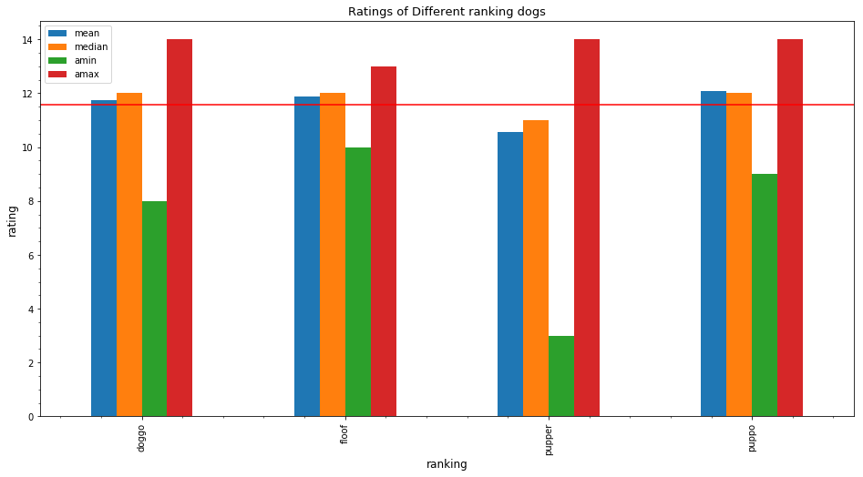

```python
df5.groupby('ranking')['rating_numerator'].agg([np.mean,np.median,np.min,np.max]).plot.bar(figsize=(16,8));
plt.axhline(rating_mean, color='r');
plt.minorticks_on()
plt.title('Ratings of Different ranking dogs',fontsize=13);
plt.xlabel('ranking',fontsize=12);
plt.ylabel('rating',fontsize=12);
```

```python
# 用箱线图
df5.boxplot(column='rating_numerator',by='ranking',showmeans=True,figsize=(10,5))
plt.axhline(rating_mean, color='r');
```

[output not shown]

**转发数和喜爱数关系散点图**

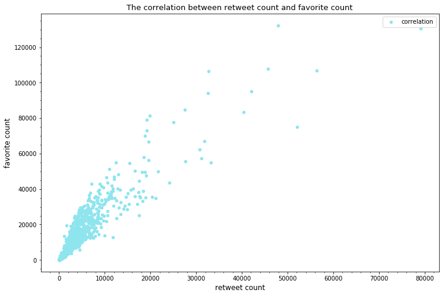

```python
df8.plot.scatter(x='retweet_count', y='favorite_count',color='#8EE5EE', label='correlation',figsize=(12,8));
plt.title('The correlation between retweet count and favorite count',fontsize=13);
plt.xlabel('retweet count',fontsize=12);
plt.ylabel('favorite count',fontsize=12);
plt.minorticks_on();
```